# Phase 2: Feature engineering + Hyperparameter tuning

- **Project Title:** Identifying Home Credit Application Default Risk
- **Group Number:** 9
- **School:** Luddy School of Engineering, Indiana University
- **Course:** INFO 526: Applied Machine Learning
- **Professor:** James Shanahan, Ph. D.
- **Date:** April 20, 2021
- **Group Members (from top left to bottom right):**  
  Joel Klein (joeklein@iu.edu), Ashley Thornton (ashthorn@iu.edu)  
  Rakesh Jothishankar (rjothis@iu.edu), Suriyadeepan Narayanasamy (sunara@iu.edu)

[figure not shown]

# Abstract

Many consumers struggle receiving loan support from banks due to lacking credit history. Home Credit is a service whose goal is to provide loan opportunities for this underserved population. Failing to build and implement an accurate repayment detection method assumes major consequences. Missed financial interest unfolds if a loan is granted to consumers likely to default, Home Credit may not recoup the principal. This paper aims to address this issue by proposing a machine learning approach using Home Credit internal and external loan application and credit payment history data for automatic loan default detection. We introduce a simple and explainable logistic regression algorithm with the loan application data. Additionally, we explore more advanced machine learning and deep learning algorithms such as gradient boosting machines and neural networks to improve default classification. The results will show strong performance comparable to existing algorithms scoring near the top of the open-source Kaggle leaderboard.

# Project Description

The main project objective is to build a machine learning classification algorithm with current and existing loan application and payment history data to determine if a new Home Credit loan applicant will default on a loan. This project will abide by the Cross Industry Standard Process for Data Mining (CRISP-DM) framework to build a valuable default detection system. The CRISP-DM framework consists of six revolving sections: business understanding, data understanding, data preparation, modeling, evaluation, and deployment. Since this modeling exercise is for research purposes only, the deployment step is ignored. The first phase of the project is to complete one iteration with available data to model and evaluate a regularized logistic regression model for default detection. The following file contains the exploratory data analysis and initial baseline model for the project "Identifying Home Credit Application Default Risk". Modeling has been performed using the data extracted from [Home Credit Default Risk (HCDR) Kaggle Competition](https://www.kaggle.com/c/home-credit-default-risk/).

[figure not shown]

# Background on Home Credit Group & the Data

## Some of the challenges

1. Dataset size
   - (688 meg uncompressed) with millions of rows of data
   - 2.71 Gig of data uncompressed
- Dealing with missing data
- Imbalanced datasets
- Summarizing transaction data

## Back ground Home Credit Group

Many people struggle to get loans due to insufficient or non-existent credit histories. Unfortunately, this population is often taken advantage of by untrustworthy lenders.

### Home Credit Group

Home Credit strives to broaden financial inclusion for the unbanked population by providing a positive and safe borrowing experience. In order to make sure this underserved population has a positive loan experience, Home Credit makes use of a variety of alternative data--including telco and transactional information--to predict their clients' repayment abilities.

While Home Credit is currently using various statistical and machine learning methods to make these predictions, they're challenging Kagglers to help them unlock the full potential of their data. Doing so will ensure that clients capable of repayment are not rejected and that loans are given with a principal, maturity, and repayment calendar that will empower their clients to be successful.

## Background on the dataset

Home Credit is a non-banking financial institution, founded in 1997 in the Czech Republic.

The company operates in 14 countries (including United States, Russia, Kazahstan, Belarus, China, India) and focuses on lending primarily to people with little or no credit history which will either not obtain loans or became victims of untrustworthly lenders.

Home Credit group has over 29 million customers, total assests of 21 billions Euro, over 160 millions loans, with the majority in Asia and and almost half of them in China (as of 19-05-2018).

While Home Credit is currently using various statistical and machine learning methods to make these predictions, they're challenging Kagglers to help them unlock the full potential of their data. Doing so will ensure that clients capable of repayment are not rejected and that loans are given with a principal, maturity, and repayment calendar that will empower their clients to be successful.

## Data files overview

There are 7 different sources of data:

- **application_train/application_test:** the main training and testing data with information about each loan application at Home Credit. Every loan has its own row and is identified by the feature SK_ID_CURR. The training application data comes with the TARGET indicating **0: the loan was repaid** or **1: the loan was not repaid**. The target variable defines if the client had payment difficulties meaning he/she had late payment more than X days on at least one of the first Y installments of the loan. Such case is marked as 1 while other all other cases as 0.
- **bureau:** data concerning client's previous credits from other financial institutions. Each previous credit has its own row in bureau, but one loan in the application data can have multiple previous credits.
- **bureau_balance:** monthly data about the previous credits in bureau. Each row is one month of a previous credit, and a single previous credit can have multiple rows, one for each month of the credit length.
- **previous_application:** previous applications for loans at Home Credit of clients who have loans in the application data. Each current loan in the application data can have multiple previous loans. Each previous application has one row and is identified by the feature SK_ID_PREV.
- **POS_CASH_balance:** monthly data about previous point of sale or cash loans clients have had with Home Credit. Each row is one month of a previous point of sale or cash loan, and a single previous loan can have many rows.
- credit_card_balance: monthly data about previous credit cards clients have had with Home Credit. Each row is one month of a credit card balance, and a single credit card can have many rows.
- **installments_payment:** payment history for previous loans at Home Credit. There is one row for every made payment and one row for every missed payment.
- **credit_card_balance:** monthly balance of client's previous credit card loans in Home Credit.

[figure not shown]

### Application train & test datasets

- **application_train/application_test:** the main training and testing data with information about each loan application at Home Credit. Every loan has its own row and is identified by the feature SK_ID_CURR. The training application data comes with the TARGET indicating **0: the loan was repaid** or **1: the loan was not repaid**. The target variable defines if the client had payment difficulties meaning he/she had late payment more than X days on at least one of the first Y installments of the loan. Such case is marked as 1 while other all other cases as 0.

The application dataset has the most information about the client: Gender, income, family status, education ...

### Other datasets

**Note: The other data set will be incorporated in phase 2 modeling.**

- **bureau:** Data concerning client's previous credits from other financial institutions. Each previous credit has its own row in bureau, but one loan in the application data can have multiple previous credits.
- **bureau_balance:** Monthly data about the previous credits in bureau. Each row is one month of a previous credit, and a single previous credit can have multiple rows, one for each month of the credit length.
- **previous_application:** Previous applications for loans at Home Credit of clients who have loans in the application data. Each current loan in the application data can have multiple previous loans. Each previous application has one row and is identified by the feature SK_ID_PREV.
- **POS_CASH_balance:** Monthly data about previous point of sale or cash loans clients have had with Home Credit. Each row is one month of a previous point of sale or cash loan, and a single previous loan can have many rows.
- **credit_card_balance:** Monthly data about previous credit card loans clients have had with Home Credit. Each row is one month of a credit card balance, and a single credit card can have many rows.
- **installments_payment:** Payment history for previous loans at Home Credit. There is one row for every made payment and one row for every missed payment.

# Environment setup

The code in section 1.1 is a repeat of the code in the first EDA notebook in order to bring in the data.

### Libraries

```python
# data manipulation
import numpy as np
import pandas as pd

import os
import zipfile

# plotting
import seaborn as sns
import matplotlib.pyplot as plt
from pandas.plotting import scatter_matrix

# splitting
from sklearn.model_selection import train_test_split

# preprocessing
from sklearn.impute import SimpleImputer
from sklearn.preprocessing import MinMaxScaler, StandardScaler, OneHotEncoder, LabelEncoder

# pipelines
from sklearn.svm import LinearSVC
from sklearn.decomposition import PCA
from sklearn.compose import ColumnTransformer
from sklearn.base import BaseEstimator, TransformerMixin
from sklearn.pipeline import Pipeline, FeatureUnion, make_pipeline

# feature selection
from sklearn.feature_selection import VarianceThreshold
from sklearn.feature_selection import SelectFromModel

# models
from xgboost import XGBClassifier
from lightgbm import LGBMClassifier
from sklearn.linear_model import LogisticRegression
from sklearn.ensemble import RandomForestClassifier

# tuning
from skopt import BayesSearchCV
from sklearn.model_selection import GridSearchCV, cross_val_score, cross_validate

# model evaluation
from sklearn.metrics import accuracy_score, f1_score, roc_auc_score, classification_report, confusion_matrix, plot_confusion_matrix
```

### Global options

```python
# do not show warnings
import warnings
warnings.filterwarnings('ignore')

# set pandas display options
pd.set_option('display.max_rows', 500)
pd.set_option('display.max_columns', 500)
pd.set_option('display.width', 2000)
pd.set_option('display.max_colwidth', 2000)
```

### Directories

```python
# Remove comment from below lines, if running on Colab
from google.colab import drive
drive.mount('/content/drive')
```

```python
# Remove comment from below lines, if running on Colab
DATA_DIR = "/content/drive/MyDrive/final-project-HCDR/data/home-credit-default-risk"

MODEL_DIR = "/content/drive/MyDrive/final-project-HCDR/output/models"

REPORT_DIR = "/content/drive/MyDrive/final-project-HCDR/output/reports"

SUBMISSION_DIR = "/content/drive/MyDrive/final-project-HCDR/output/submissions"
```

## Functions

### Data Load

```python
# define a function for loading in dataset
def load_data(in_path, name):
    df = pd.read_csv(in_path)
    print(f"{name}: shape is {df.shape}")
    print(df.info())
    display(df.head(5))
    return df
```

### Get Feature Names

```python
# function to get the feature names from a data pipeline
def get_feature_names(pipe, zv = False, feature_selection = False):

  if (not (zv|feature_selection)):
    column_names = numerical_features + \
                   list(pipe.named_steps['preparation'].transformers_[1][1].named_steps["ohe"].get_feature_names(categorical_features))

  elif (zv & feature_selection):
    column_names_step1 = numerical_features + \
                         list(pipe.named_steps['preparation'].transformers_[1][1].named_steps["ohe"].get_feature_names(categorical_features))

    support = pipe.named_steps['zv'].get_support()
    column_names_step2 = np.array(column_names_step1)[support]

    support = pipe.named_steps['feature_selection'].get_support()
    column_names = np.array(column_names_step2)[support]


  elif (zv):
    column_names_step1 = numerical_features + \
                         list(pipe.named_steps['preparation'].transformers_[1][1].named_steps["ohe"].get_feature_names(categorical_features))

    support = pipe.named_steps['zv'].get_support()
    column_names = np.array(column_names_step1)[support]


  elif (feature_selection):
    column_names_step1 = numerical_features + \
                         list(pipe.named_steps['preparation'].transformers_[1][1].named_steps["ohe"].get_feature_names(categorical_features))

    support = pipe.named_steps['feature_selection'].get_support()
    column_names = np.array(column_names_step1)[support]

  return(list(column_names))
```

### Feature Importance

```python
# Function to plot feature importances for LR model
def lr_feature_importance_plot(clf, pca = False, names=[], n=10):

    if (pca):

      feature_importance = abs(clf.named_steps['logistic'].coef_[0])
      feature_importance = 100.0 * (feature_importance / feature_importance.max())
      sorted_idx = np.argsort(feature_importance)
      pos = np.arange(sorted_idx.shape[0]) + .5

      names=[str(i) for i in list(range(0, len(feature_importance)))]

      fig = plt.figure(figsize=(8, 6), dpi=80)
      ax = fig.add_subplot(1, 1, 1)
      ax.barh(pos[-n:], feature_importance[sorted_idx][-n:], align='center')
      ax.set_yticks(pos[-n:])
      ax.set_yticklabels(np.array(names)[sorted_idx][-n:], fontsize=8)
      ax.set_xlabel('Relative Feature Importance')

      plt.tight_layout()
      plt.show()

    else:
      feature_importance = abs(clf.named_steps['logistic'].coef_[0])
      feature_importance = 100.0 * (feature_importance / feature_importance.max())
      sorted_idx = np.argsort(feature_importance)
      pos = np.arange(sorted_idx.shape[0]) + .5

      fig = plt.figure(figsize=(8, 6), dpi=80)
      ax = fig.add_subplot(1, 1, 1)
      ax.barh(pos[-n:], feature_importance[sorted_idx][-n:], align='center')
      ax.set_yticks(pos[-n:])
      ax.set_yticklabels(np.array(names)[sorted_idx][-n:], fontsize=8)
      ax.set_xlabel('Relative Feature Importance')

      plt.tight_layout()
      plt.show()

    print("There are",len(feature_importance[feature_importance == 0]),"features that have 0 importance.")
```

```python
# Function to plot feature importances for Tree model
def tree_feature_importance_plot(clf, step_name, pca = False, names=[], n=10):

    if (pca):
      feature_importance = abs(clf.named_steps[step_name].feature_importances_)
      sorted_idx = np.argsort(feature_importance)
      pos = np.arange(sorted_idx.shape[0]) + .5

      names=[str(i) for i in list(range(0, len(feature_importance)))]

      fig = plt.figure(figsize=(8, 6), dpi=80)
      ax = fig.add_subplot(1, 1, 1)
      ax.barh(pos[-n:], feature_importance[sorted_idx][-n:], align='center')
      ax.set_yticks(pos[-n:])
      ax.set_yticklabels(np.array(names)[sorted_idx][-n:], fontsize=8)
      ax.set_xlabel('Relative Feature Importance')

      plt.tight_layout()
      plt.show()

    else:
      feature_importance = abs(clf.named_steps[step_name].feature_importances_)
      sorted_idx = np.argsort(feature_importance)
      pos = np.arange(sorted_idx.shape[0]) + .5

      fig = plt.figure(figsize=(8, 6), dpi=80)
      ax = fig.add_subplot(1, 1, 1)
      ax.barh(pos[-n:], feature_importance[sorted_idx][-n:], align='center')
      ax.set_yticks(pos[-n:])
      ax.set_yticklabels(np.array(names)[sorted_idx][-n:], fontsize=8)
      ax.set_xlabel('Relative Feature Importance')

      plt.tight_layout()
      plt.show()

    print("There are",len(feature_importance[feature_importance == 0]),"features that have 0 importance.")
```

## Custom Transformers

### Feature Additions

```python
# Create installment features
class InstallmentFeaturesAdder(BaseEstimator, TransformerMixin):
    def __init__(self):
        self.l = []

    def fit(self, X, y=None):
        return self

    def transform(self, X, y=None):

        # new feature creation from the Installment Payment file
        X['PAY_IS_LATE'] = X['DAYS_INSTALMENT'] - X['DAYS_ENTRY_PAYMENT']
        X['AMT_MISSED'] = X['AMT_INSTALMENT'] - X['AMT_PAYMENT']

        return X
```

```python
# Create installment features
class CreditCardBalanceFeaturesAdder(BaseEstimator, TransformerMixin):
    def __init__(self):
        self.l = []

    def fit(self, X, y=None):
        return self

    def transform(self, X, y=None):

        # new feature creation from the Credit Card file
        X['DPD_MISSED'] = X['SK_DPD'] - X['SK_DPD_DEF']
        X['CREDIT_UTILIZED'] = X['AMT_CREDIT_LIMIT_ACTUAL'] - X['AMT_DRAWINGS_CURRENT']
        X['MIN_CREDIT_AMTMISS'] = X['AMT_INST_MIN_REGULARITY'] - X['AMT_PAYMENT_CURRENT']

        return X
```

```python
# Create previous application features
class PreviousApplicationFeaturesAdder(BaseEstimator, TransformerMixin):
    def __init__(self):
        self.l = []

    def fit(self, X, y=None):
        return self

    def transform(self, X, y=None):

        # new feature in the Previous Application file
        X['INTEREST'] = X['CNT_PAYMENT'] * X['AMT_ANNUITY'] - X['AMT_CREDIT']
        X['INTEREST_PER_CREDIT'] = X['INTEREST'] / X['AMT_CREDIT']
        X['CREDIT_SUCCESS'] = X['AMT_APPLICATION'] - X['AMT_CREDIT']
        X['INTEREST_RT'] = 2 * 12 * X['INTEREST'] / (X['AMT_CREDIT'] * (X['CNT_PAYMENT'] + 1))

        return X
```

```python
# Create application features
class ApplicationFeaturesAdder(BaseEstimator, TransformerMixin):
    def __init__(self):
        self.l = []

    def fit(self, X, y=None):
        return self

    def transform(self, X, y=None):

        # credit to income ratio
        X['CREDIT_INCOME_RATIO'] = X['AMT_CREDIT'] / X['AMT_INCOME_TOTAL']

        # annuity to income ratio
        X['ANNUITY_INCOME_RATIO'] = X['AMT_ANNUITY'] / X['AMT_INCOME_TOTAL']

        # length of the credit term
        X['CREDIT_LENGTH'] = X['AMT_ANNUITY'] / X['AMT_CREDIT']

        # what is income to age ratio
        X['INCOME_AGE_RATIO'] = X['AMT_INCOME_TOTAL'] / X['DAYS_BIRTH']

        # what is credit to age ratio
        X['CREDIT_AGE_RATIO'] = X['AMT_CREDIT'] / X['DAYS_BIRTH']

        # what percent of applicants life have they been working at recent company
        X['DAYS_EMPLOYED_PERCENT'] = X['DAYS_EMPLOYED'] / X['DAYS_BIRTH']

        # add liability feature code
        conditions_temp = [
            (X['FLAG_OWN_CAR'] == 'Y') & (X['FLAG_OWN_REALTY'] == 'Y'),
            (X['FLAG_OWN_CAR'] == 'N') & (X['FLAG_OWN_REALTY'] == 'Y'),
            (X['FLAG_OWN_CAR'] == 'Y') & (X['FLAG_OWN_REALTY'] == 'N'),
            (X['FLAG_OWN_CAR'] == 'N') & (X['FLAG_OWN_REALTY'] == 'N')]

        values_temp = ['0', '1', '2', '3']

        X['HAS_LIBAILITY'] = np.select(conditions_temp, values_temp)

        return X
```

### Feature Aggregation

```python
# Create aggregate features
class FeaturesAggregater(BaseEstimator, TransformerMixin):
    def __init__(self, grouping_feature = None, previousDFcolumns = None, prefix = ''):

        self.prefix = prefix
        self.previousDFcolumns = previousDFcolumns
        self.grouping_feature = grouping_feature
        self.numeric_stats = ["min", "max", "mean", "count", "sum"]
        self.categorical_stats = ["mean", "count", "sum"]
        self.agg_op_features = {}
        self.agg_features_names = [self.grouping_feature]

    def fit(self, X, y=None):
        return self

    def transform(self, X, y=None):

        numeric_cols = list(X.columns[X.columns.isin(self.previousDFcolumns)])
        numeric_cols = [num for num in numeric_cols if num not in ['SK_ID_CURR','SK_ID_PREV','SK_ID_BUREAU']]
        categorical_cols = list(X.columns[~X.columns.isin(self.previousDFcolumns)])

        for f in numeric_cols:
            self.agg_op_features[f] = self.numeric_stats
            self.agg_features_names = self.agg_features_names + [self.prefix + "_" + f + "_" + s for s in self.numeric_stats]

        for f in categorical_cols:
            self.agg_op_features[f] = self.categorical_stats
            self.agg_features_names = self.agg_features_names + [self.prefix + "_" + f + "_" + s for s in self.categorical_stats]

        result = X.groupby(self.grouping_feature).agg(self.agg_op_features)
        result.columns = result.columns.droplevel()
        result = result.reset_index(level=[self.grouping_feature])
        result.columns = self.agg_features_names
        return result
```

### One Hot Encoder

```python
# Create aggregate features (via pipeline)
class getDummies(BaseEstimator, TransformerMixin):
    def __init__(self, columns=None): # no *args or **kargs
        self.columns = columns

    def fit(self, X, y=None):
        return self

    def transform(self, X, y=None):
        result = pd.get_dummies(X, columns = self.columns)
        return result
```

### Missing Data Removal

```python
# Remove missing columns
class MissingFeatureRemover(BaseEstimator, TransformerMixin):
    def __init__(self, threshold = .6):
        self.threshold = threshold

    def fit(self, X, y=None):

        # get the percent of missingness in features
        percent = (X.isnull().sum()/X.isnull().count()).sort_values(ascending = False)

        # turn into a data frame
        missing_application_train_data  = pd.DataFrame(percent, columns=['Percent'])

        # get the columns with missingness exceeding the threshold
        self.columns_to_drop = list(missing_application_train_data.index[missing_application_train_data['Percent'] > self.threshold])

        return self

    def transform(self, X, y=None):

        # drop the columns with missingness over the threshold
        X = X.drop(columns = self.columns_to_drop, axis=1)

        return X
```

### Collinear Feature Removal

```python
# Remove features with high colli
class CollinearFeatureRemover(BaseEstimator, TransformerMixin):
    def __init__(self, threshold = .9):
        self.threshold = threshold

    def fit(self, X, y=None):

        # get the correlation matrix for the entire dataset after one hot encoding features
#        correlation_matrix = X.head(1000).corr().abs()
        correlation_matrix = X.sample(10000).corr().abs()

        # get only the lower portion of collinearity matrix
        lower = correlation_matrix.where(np.tril(np.ones(correlation_matrix.shape), k=-1).astype(np.bool))

        # get the fields with correlation above threshold
        self.columns_to_drop = [index for index in lower.index if any(lower.loc[index] > self.threshold)]

        return self

    def transform(self, X, y=None):

        # drop the columns with collinearity over the threshold
        X = X.drop(columns = self.columns_to_drop, axis=1)

        return X
```

### Removal of Zero Variance

```python
# Remove features with near zero variance
class NearZeroVarianceFeatureRemover(BaseEstimator, TransformerMixin):
    def __init__(self, threshold = 0):
        self.threshold = threshold

    def fit(self, X, y=None):

        # get the fields with correlation above threshold
        self.columns_to_drop = [col for col in X.select_dtypes([np.number]).columns if np.nanvar(X[col]) <= self.threshold]

        return self

    def transform(self, X, y=None):

        # drop the columns with collinearity over the threshold
        X = X.drop(columns = self.columns_to_drop, axis=1)

        return X
```

## Data Load

```python
%%time
datasets = {}

ds_names = ("application_train", "application_test", "bureau","bureau_balance","credit_card_balance","installments_payments",
            "previous_application","POS_CASH_balance")

for ds_name in ds_names:
    datasets[ds_name] = load_data(os.path.join(DATA_DIR, f'{ds_name}.csv'), ds_name)
```

```
application_train: shape is (307511, 122)
<class 'pandas.core.frame.DataFrame'>
RangeIndex: 307511 entries, 0 to 307510
Columns: 122 entries, SK_ID_CURR to AMT_REQ_CREDIT_BUREAU_YEAR
dtypes: float64(65), int64(41), object(16)
memory usage: 286.2+ MB
None
```

|  | SK_ID_CURR | TARGET | NAME_CONTRACT_TYPE | CODE_GENDER | FLAG_OWN_CAR | FLAG_OWN_REALTY | CNT_CHILDREN | AMT_INCOME_TOTAL | AMT_CREDIT | AMT_ANNUITY | AMT_GOODS_PRICE | NAME_TYPE_SUITE | NAME_INCOME_TYPE | NAME_EDUCATION_TYPE | NAME_FAMILY_STATUS | NAME_HOUSING_TYPE | REGION_POPULATION_RELATIVE | DAYS_BIRTH | DAYS_EMPLOYED | DAYS_REGISTRATION | DAYS_ID_PUBLISH | OWN_CAR_AGE | FLAG_MOBIL | FLAG_EMP_PHONE | FLAG_WORK_PHONE | FLAG_CONT_MOBILE | FLAG_PHONE | FLAG_EMAIL | OCCUPATION_TYPE | … |
| --- | --- | --- | --- | --- | --- | --- | --- | --- | --- | --- | --- | --- | --- | --- | --- | --- | --- | --- | --- | --- | --- | --- | --- | --- | --- | --- | --- | --- | --- | --- |
| 0 | 100002 | 1 | Cash loans | M | N | Y | 0 | 202500.0 | 406597.5 | 24700.5 | 351000.0 | Unaccompanied | Working | Secondary / secondary special | Single / not married | House / apartment | 0.018801 | -9461 | -637 | -3648.0 | -2120 | NaN | 1 | 1 | 0 | 1 | 1 | 0 | Laborers | … |
| 1 | 100003 | 0 | Cash loans | F | N | N | 0 | 270000.0 | 1293502.5 | 35698.5 | 1129500.0 | Family | State servant | Higher education | Married | House / apartment | 0.003541 | -16765 | -1188 | -1186.0 | -291 | NaN | 1 | 1 | 0 | 1 | 1 | 0 | Core staff | … |
| 2 | 100004 | 0 | Revolving loans | M | Y | Y | 0 | 67500.0 | 135000.0 | 6750.0 | 135000.0 | Unaccompanied | Working | Secondary / secondary special | Single / not married | House / apartment | 0.010032 | -19046 | -225 | -4260.0 | -2531 | 26.0 | 1 | 1 | 1 | 1 | 1 | 0 | Laborers | … |
| 3 | 100006 | 0 | Cash loans | F | N | Y | 0 | 135000.0 | 312682.5 | 29686.5 | 297000.0 | Unaccompanied | Working | Secondary / secondary special | Civil marriage | House / apartment | 0.008019 | -19005 | -3039 | -9833.0 | -2437 | NaN | 1 | 1 | 0 | 1 | 0 | 0 | Laborers | … |
| 4 | 100007 | 0 | Cash loans | M | N | Y | 0 | 121500.0 | 513000.0 | 21865.5 | 513000.0 | Unaccompanied | Working | Secondary / secondary special | Single / not married | House / apartment | 0.028663 | -19932 | -3038 | -4311.0 | -3458 | NaN | 1 | 1 | 0 | 1 | 0 | 0 | Core staff | … |

```
application_test: shape is (48744, 121)
<class 'pandas.core.frame.DataFrame'>
RangeIndex: 48744 entries, 0 to 48743
Columns: 121 entries, SK_ID_CURR to AMT_REQ_CREDIT_BUREAU_YEAR
dtypes: float64(65), int64(40), object(16)
memory usage: 45.0+ MB
None
```

|  | SK_ID_CURR | NAME_CONTRACT_TYPE | CODE_GENDER | FLAG_OWN_CAR | FLAG_OWN_REALTY | CNT_CHILDREN | AMT_INCOME_TOTAL | AMT_CREDIT | AMT_ANNUITY | AMT_GOODS_PRICE | NAME_TYPE_SUITE | NAME_INCOME_TYPE | NAME_EDUCATION_TYPE | NAME_FAMILY_STATUS | NAME_HOUSING_TYPE | REGION_POPULATION_RELATIVE | DAYS_BIRTH | DAYS_EMPLOYED | DAYS_REGISTRATION | DAYS_ID_PUBLISH | OWN_CAR_AGE | FLAG_MOBIL | FLAG_EMP_PHONE | FLAG_WORK_PHONE | FLAG_CONT_MOBILE | FLAG_PHONE | FLAG_EMAIL | OCCUPATION_TYPE | CNT_FAM_MEMBERS | … |
| --- | --- | --- | --- | --- | --- | --- | --- | --- | --- | --- | --- | --- | --- | --- | --- | --- | --- | --- | --- | --- | --- | --- | --- | --- | --- | --- | --- | --- | --- | --- |
| 0 | 100001 | Cash loans | F | N | Y | 0 | 135000.0 | 568800.0 | 20560.5 | 450000.0 | Unaccompanied | Working | Higher education | Married | House / apartment | 0.018850 | -19241 | -2329 | -5170.0 | -812 | NaN | 1 | 1 | 0 | 1 | 0 | 1 | NaN | 2.0 | … |
| 1 | 100005 | Cash loans | M | N | Y | 0 | 99000.0 | 222768.0 | 17370.0 | 180000.0 | Unaccompanied | Working | Secondary / secondary special | Married | House / apartment | 0.035792 | -18064 | -4469 | -9118.0 | -1623 | NaN | 1 | 1 | 0 | 1 | 0 | 0 | Low-skill Laborers | 2.0 | … |
| 2 | 100013 | Cash loans | M | Y | Y | 0 | 202500.0 | 663264.0 | 69777.0 | 630000.0 | NaN | Working | Higher education | Married | House / apartment | 0.019101 | -20038 | -4458 | -2175.0 | -3503 | 5.0 | 1 | 1 | 0 | 1 | 0 | 0 | Drivers | 2.0 | … |
| 3 | 100028 | Cash loans | F | N | Y | 2 | 315000.0 | 1575000.0 | 49018.5 | 1575000.0 | Unaccompanied | Working | Secondary / secondary special | Married | House / apartment | 0.026392 | -13976 | -1866 | -2000.0 | -4208 | NaN | 1 | 1 | 0 | 1 | 1 | 0 | Sales staff | 4.0 | … |
| 4 | 100038 | Cash loans | M | Y | N | 1 | 180000.0 | 625500.0 | 32067.0 | 625500.0 | Unaccompanied | Working | Secondary / secondary special | Married | House / apartment | 0.010032 | -13040 | -2191 | -4000.0 | -4262 | 16.0 | 1 | 1 | 1 | 1 | 0 | 0 | NaN | 3.0 | … |

```
bureau: shape is (1716428, 17)
<class 'pandas.core.frame.DataFrame'>
RangeIndex: 1716428 entries, 0 to 1716427
Data columns (total 17 columns):
 #   Column                  Dtype
---  ------                  -----
 0   SK_ID_CURR              int64
 1   SK_ID_BUREAU            int64
 2   CREDIT_ACTIVE           object
 3   CREDIT_CURRENCY         object
 4   DAYS_CREDIT             int64
 5   CREDIT_DAY_OVERDUE      int64
 6   DAYS_CREDIT_ENDDATE     float64
 7   DAYS_ENDDATE_FACT       float64
 8   AMT_CREDIT_MAX_OVERDUE  float64
 9   CNT_CREDIT_PROLONG      int64
 10  AMT_CREDIT_SUM          float64
 11  AMT_CREDIT_SUM_DEBT     float64
 12  AMT_CREDIT_SUM_LIMIT    float64
 13  AMT_CREDIT_SUM_OVERDUE  float64
 14  CREDIT_TYPE             object
 15  DAYS_CREDIT_UPDATE      int64
 16  AMT_ANNUITY             float64
dtypes: float64(8), int64(6), object(3)
memory usage: 222.6+ MB
None
```

|  | SK_ID_CURR | SK_ID_BUREAU | CREDIT_ACTIVE | CREDIT_CURRENCY | DAYS_CREDIT | CREDIT_DAY_OVERDUE | DAYS_CREDIT_ENDDATE | DAYS_ENDDATE_FACT | AMT_CREDIT_MAX_OVERDUE | CNT_CREDIT_PROLONG | AMT_CREDIT_SUM | AMT_CREDIT_SUM_DEBT | AMT_CREDIT_SUM_LIMIT | AMT_CREDIT_SUM_OVERDUE | CREDIT_TYPE | DAYS_CREDIT_UPDATE | AMT_ANNUITY |
| --- | --- | --- | --- | --- | --- | --- | --- | --- | --- | --- | --- | --- | --- | --- | --- | --- | --- |
| 0 | 215354 | 5714462 | Closed | currency 1 | -497 | 0 | -153.0 | -153.0 | NaN | 0 | 91323.0 | 0.0 | NaN | 0.0 | Consumer credit | -131 | NaN |
| 1 | 215354 | 5714463 | Active | currency 1 | -208 | 0 | 1075.0 | NaN | NaN | 0 | 225000.0 | 171342.0 | NaN | 0.0 | Credit card | -20 | NaN |
| 2 | 215354 | 5714464 | Active | currency 1 | -203 | 0 | 528.0 | NaN | NaN | 0 | 464323.5 | NaN | NaN | 0.0 | Consumer credit | -16 | NaN |
| 3 | 215354 | 5714465 | Active | currency 1 | -203 | 0 | NaN | NaN | NaN | 0 | 90000.0 | NaN | NaN | 0.0 | Credit card | -16 | NaN |
| 4 | 215354 | 5714466 | Active | currency 1 | -629 | 0 | 1197.0 | NaN | 77674.5 | 0 | 2700000.0 | NaN | NaN | 0.0 | Consumer credit | -21 | NaN |

```
bureau_balance: shape is (27299925, 3)
<class 'pandas.core.frame.DataFrame'>
RangeIndex: 27299925 entries, 0 to 27299924
Data columns (total 3 columns):
 #   Column          Dtype
---  ------          -----
 0   SK_ID_BUREAU    int64
 1   MONTHS_BALANCE  int64
 2   STATUS          object
dtypes: int64(2), object(1)
memory usage: 624.8+ MB
None
```

|  | SK_ID_BUREAU | MONTHS_BALANCE | STATUS |
| --- | --- | --- | --- |
| 0 | 5715448 | 0 | C |
| 1 | 5715448 | -1 | C |
| 2 | 5715448 | -2 | C |
| 3 | 5715448 | -3 | C |
| 4 | 5715448 | -4 | C |

```
credit_card_balance: shape is (3840312, 23)
<class 'pandas.core.frame.DataFrame'>
RangeIndex: 3840312 entries, 0 to 3840311
Data columns (total 23 columns):
 #   Column                      Dtype
---  ------                      -----
 0   SK_ID_PREV                  int64
 1   SK_ID_CURR                  int64
 2   MONTHS_BALANCE              int64
 3   AMT_BALANCE                 float64
 4   AMT_CREDIT_LIMIT_ACTUAL     int64
 5   AMT_DRAWINGS_ATM_CURRENT    float64
 6   AMT_DRAWINGS_CURRENT        float64
 7   AMT_DRAWINGS_OTHER_CURRENT  float64
 8   AMT_DRAWINGS_POS_CURRENT    float64
```

[output cut: 17 more lines]

|  | SK_ID_PREV | SK_ID_CURR | MONTHS_BALANCE | AMT_BALANCE | AMT_CREDIT_LIMIT_ACTUAL | AMT_DRAWINGS_ATM_CURRENT | AMT_DRAWINGS_CURRENT | AMT_DRAWINGS_OTHER_CURRENT | AMT_DRAWINGS_POS_CURRENT | AMT_INST_MIN_REGULARITY | AMT_PAYMENT_CURRENT | AMT_PAYMENT_TOTAL_CURRENT | AMT_RECEIVABLE_PRINCIPAL | AMT_RECIVABLE | AMT_TOTAL_RECEIVABLE | CNT_DRAWINGS_ATM_CURRENT | CNT_DRAWINGS_CURRENT | CNT_DRAWINGS_OTHER_CURRENT | CNT_DRAWINGS_POS_CURRENT | CNT_INSTALMENT_MATURE_CUM | NAME_CONTRACT_STATUS | SK_DPD | SK_DPD_DEF |
| --- | --- | --- | --- | --- | --- | --- | --- | --- | --- | --- | --- | --- | --- | --- | --- | --- | --- | --- | --- | --- | --- | --- | --- |
| 0 | 2562384 | 378907 | -6 | 56.970 | 135000 | 0.0 | 877.5 | 0.0 | 877.5 | 1700.325 | 1800.0 | 1800.0 | 0.000 | 0.000 | 0.000 | 0.0 | 1 | 0.0 | 1.0 | 35.0 | Active | 0 | 0 |
| 1 | 2582071 | 363914 | -1 | 63975.555 | 45000 | 2250.0 | 2250.0 | 0.0 | 0.0 | 2250.000 | 2250.0 | 2250.0 | 60175.080 | 64875.555 | 64875.555 | 1.0 | 1 | 0.0 | 0.0 | 69.0 | Active | 0 | 0 |
| 2 | 1740877 | 371185 | -7 | 31815.225 | 450000 | 0.0 | 0.0 | 0.0 | 0.0 | 2250.000 | 2250.0 | 2250.0 | 26926.425 | 31460.085 | 31460.085 | 0.0 | 0 | 0.0 | 0.0 | 30.0 | Active | 0 | 0 |
| 3 | 1389973 | 337855 | -4 | 236572.110 | 225000 | 2250.0 | 2250.0 | 0.0 | 0.0 | 11795.760 | 11925.0 | 11925.0 | 224949.285 | 233048.970 | 233048.970 | 1.0 | 1 | 0.0 | 0.0 | 10.0 | Active | 0 | 0 |
| 4 | 1891521 | 126868 | -1 | 453919.455 | 450000 | 0.0 | 11547.0 | 0.0 | 11547.0 | 22924.890 | 27000.0 | 27000.0 | 443044.395 | 453919.455 | 453919.455 | 0.0 | 1 | 0.0 | 1.0 | 101.0 | Active | 0 | 0 |

```
installments_payments: shape is (13605401, 8)
<class 'pandas.core.frame.DataFrame'>
RangeIndex: 13605401 entries, 0 to 13605400
Data columns (total 8 columns):
 #   Column                  Dtype
---  ------                  -----
 0   SK_ID_PREV              int64
 1   SK_ID_CURR              int64
 2   NUM_INSTALMENT_VERSION  float64
 3   NUM_INSTALMENT_NUMBER   int64
 4   DAYS_INSTALMENT         float64
 5   DAYS_ENTRY_PAYMENT      float64
 6   AMT_INSTALMENT          float64
 7   AMT_PAYMENT             float64
dtypes: float64(5), int64(3)
memory usage: 830.4 MB
None
```

|  | SK_ID_PREV | SK_ID_CURR | NUM_INSTALMENT_VERSION | NUM_INSTALMENT_NUMBER | DAYS_INSTALMENT | DAYS_ENTRY_PAYMENT | AMT_INSTALMENT | AMT_PAYMENT |
| --- | --- | --- | --- | --- | --- | --- | --- | --- |
| 0 | 1054186 | 161674 | 1.0 | 6 | -1180.0 | -1187.0 | 6948.360 | 6948.360 |
| 1 | 1330831 | 151639 | 0.0 | 34 | -2156.0 | -2156.0 | 1716.525 | 1716.525 |
| 2 | 2085231 | 193053 | 2.0 | 1 | -63.0 | -63.0 | 25425.000 | 25425.000 |
| 3 | 2452527 | 199697 | 1.0 | 3 | -2418.0 | -2426.0 | 24350.130 | 24350.130 |
| 4 | 2714724 | 167756 | 1.0 | 2 | -1383.0 | -1366.0 | 2165.040 | 2160.585 |

```
previous_application: shape is (1670214, 37)
<class 'pandas.core.frame.DataFrame'>
RangeIndex: 1670214 entries, 0 to 1670213
Data columns (total 37 columns):
 #   Column                       Non-Null Count    Dtype
---  ------                       --------------    -----
 0   SK_ID_PREV                   1670214 non-null  int64
 1   SK_ID_CURR                   1670214 non-null  int64
 2   NAME_CONTRACT_TYPE           1670214 non-null  object
 3   AMT_ANNUITY                  1297979 non-null  float64
 4   AMT_APPLICATION              1670214 non-null  float64
 5   AMT_CREDIT                   1670213 non-null  float64
 6   AMT_DOWN_PAYMENT             774370 non-null   float64
 7   AMT_GOODS_PRICE              1284699 non-null  float64
 8   WEEKDAY_APPR_PROCESS_START   1670214 non-null  object
```

[output cut: 31 more lines]

|  | SK_ID_PREV | SK_ID_CURR | NAME_CONTRACT_TYPE | AMT_ANNUITY | AMT_APPLICATION | AMT_CREDIT | AMT_DOWN_PAYMENT | AMT_GOODS_PRICE | WEEKDAY_APPR_PROCESS_START | HOUR_APPR_PROCESS_START | FLAG_LAST_APPL_PER_CONTRACT | NFLAG_LAST_APPL_IN_DAY | RATE_DOWN_PAYMENT | RATE_INTEREST_PRIMARY | RATE_INTEREST_PRIVILEGED | NAME_CASH_LOAN_PURPOSE | NAME_CONTRACT_STATUS | DAYS_DECISION | NAME_PAYMENT_TYPE | CODE_REJECT_REASON | NAME_TYPE_SUITE | NAME_CLIENT_TYPE | NAME_GOODS_CATEGORY | NAME_PORTFOLIO | NAME_PRODUCT_TYPE | CHANNEL_TYPE | SELLERPLACE_AREA | NAME_SELLER_INDUSTRY | CNT_PAYMENT | … |
| --- | --- | --- | --- | --- | --- | --- | --- | --- | --- | --- | --- | --- | --- | --- | --- | --- | --- | --- | --- | --- | --- | --- | --- | --- | --- | --- | --- | --- | --- | --- |
| 0 | 2030495 | 271877 | Consumer loans | 1730.430 | 17145.0 | 17145.0 | 0.0 | 17145.0 | SATURDAY | 15 | Y | 1 | 0.0 | 0.182832 | 0.867336 | XAP | Approved | -73 | Cash through the bank | XAP | NaN | Repeater | Mobile | POS | XNA | Country-wide | 35 | Connectivity | 12.0 | … |
| 1 | 2802425 | 108129 | Cash loans | 25188.615 | 607500.0 | 679671.0 | NaN | 607500.0 | THURSDAY | 11 | Y | 1 | NaN | NaN | NaN | XNA | Approved | -164 | XNA | XAP | Unaccompanied | Repeater | XNA | Cash | x-sell | Contact center | -1 | XNA | 36.0 | … |
| 2 | 2523466 | 122040 | Cash loans | 15060.735 | 112500.0 | 136444.5 | NaN | 112500.0 | TUESDAY | 11 | Y | 1 | NaN | NaN | NaN | XNA | Approved | -301 | Cash through the bank | XAP | Spouse, partner | Repeater | XNA | Cash | x-sell | Credit and cash offices | -1 | XNA | 12.0 | … |
| 3 | 2819243 | 176158 | Cash loans | 47041.335 | 450000.0 | 470790.0 | NaN | 450000.0 | MONDAY | 7 | Y | 1 | NaN | NaN | NaN | XNA | Approved | -512 | Cash through the bank | XAP | NaN | Repeater | XNA | Cash | x-sell | Credit and cash offices | -1 | XNA | 12.0 | … |
| 4 | 1784265 | 202054 | Cash loans | 31924.395 | 337500.0 | 404055.0 | NaN | 337500.0 | THURSDAY | 9 | Y | 1 | NaN | NaN | NaN | Repairs | Refused | -781 | Cash through the bank | HC | NaN | Repeater | XNA | Cash | walk-in | Credit and cash offices | -1 | XNA | 24.0 | … |

```
POS_CASH_balance: shape is (10001358, 8)
<class 'pandas.core.frame.DataFrame'>
RangeIndex: 10001358 entries, 0 to 10001357
Data columns (total 8 columns):
 #   Column                 Dtype
---  ------                 -----
 0   SK_ID_PREV             int64
 1   SK_ID_CURR             int64
 2   MONTHS_BALANCE         int64
 3   CNT_INSTALMENT         float64
 4   CNT_INSTALMENT_FUTURE  float64
 5   NAME_CONTRACT_STATUS   object
 6   SK_DPD                 int64
 7   SK_DPD_DEF             int64
dtypes: float64(2), int64(5), object(1)
memory usage: 610.4+ MB
None
```

|  | SK_ID_PREV | SK_ID_CURR | MONTHS_BALANCE | CNT_INSTALMENT | CNT_INSTALMENT_FUTURE | NAME_CONTRACT_STATUS | SK_DPD | SK_DPD_DEF |
| --- | --- | --- | --- | --- | --- | --- | --- | --- |
| 0 | 1803195 | 182943 | -31 | 48.0 | 45.0 | Active | 0 | 0 |
| 1 | 1715348 | 367990 | -33 | 36.0 | 35.0 | Active | 0 | 0 |
| 2 | 1784872 | 397406 | -32 | 12.0 | 9.0 | Active | 0 | 0 |
| 3 | 1903291 | 269225 | -35 | 48.0 | 42.0 | Active | 0 | 0 |
| 4 | 2341044 | 334279 | -35 | 36.0 | 35.0 | Active | 0 | 0 |

```
CPU times: user 37.6 s, sys: 2.99 s, total: 40.6 s
Wall time: 49.4 s
```

```python
for ds_name in datasets.keys():
    print(f'dataset {ds_name:24}: [ {datasets[ds_name].shape[0]:10,}, {datasets[ds_name].shape[1]}]')
```

```
dataset application_train       : [    307,511, 122]
dataset application_test        : [     48,744, 121]
dataset bureau                  : [  1,716,428, 17]
dataset bureau_balance          : [ 27,299,925, 3]
dataset credit_card_balance     : [  3,840,312, 23]
dataset installments_payments   : [ 13,605,401, 8]
dataset previous_application    : [  1,670,214, 37]
dataset POS_CASH_balance        : [ 10,001,358, 8]
```

```python
appTrainDF = datasets["application_train"]
appTestDF = datasets["application_test"]
bureauDF = datasets["bureau"]
bureauBalDF = datasets["bureau_balance"]
creditCardBalDF = datasets["credit_card_balance"]
installmentPayDF = datasets["installments_payments"]
previousAppDF = datasets["previous_application"]
cashBalDF = datasets["POS_CASH_balance"]
```

```python
# delete objects no longer needed for memory
import gc
gc.enable()
del datasets
gc.collect()
```

```
150
```

# Phase 1

## Modeling

The **initial baseline** model will be fit only with the application data set to predict credit default.

**Data:**

- Loan application data

**Validation strategy:**

- Data is split such that 80% is in training data and 20% is held out in testing data
- 5 fold cross validation will be used for tuning and estimating accuracy before evaluating on test data - see tuning section below.

**Features:**

- All numeric and categorical

**Data preprocessing:**

**Tuning strategy:**

- The hyperparameter tuning will be completed using a random 10% of the training data. The hyperparameters will be chosen based on the subset generating the highest 5 fold validation area under the roc curve.
- We will use the remaining 90% of the training data to perform 5 fold cross validation with the best hyperparameters from the tuning process to gather estimates of how the model will perform on unseen data.

**Algorithms:**

- Elastic Net Logistic Regression
- Random Forest
- XGBoost

**Experiments:**

- Elastic Net Logistic Regression with all loan application features (baseline)

**Evaluation:**

- Main metric to optimize: Area under ROC curve
- Other metrics to evaluate: precision, recall, f1 score, classification accuracy, confusion matrix

### Split data

```python
# assign the input and response features
X = appTrainDF.drop(['SK_ID_CURR', 'TARGET'], axis = 1)
y = appTrainDF['TARGET']
```

```python
# split data such that 80% in training and 20% in test
x_train, x_test, y_train, y_test = train_test_split(X, y, stratify=y, test_size=.2, random_state=42)
```

```python
# print the shape of the training data
x_train.shape
```

```
(246008, 120)
```

#### Generate a smaller sample for tuning

A standard 4 Core and 16 GB RAM does not have enough compute power to train a model of this size. Thus we will do an additional split with the training data in order for performing hyperparameter tuning.

The hyperparameter tuning will be completed using a random 10% of the training data. The hyperparameters will be chosen based on the subset generating the highest 5 fold validation area under the roc curve.

We will use the remaining 90% of the training data to perform 5 fold cross validation with the best hyperparameters from the tuning process to gather estimates of how the model will perform on unseen data.

```python
# split data such that 10% is used for tuning, other 90% used for cross fold validation with best hyperparameters
x_sample_10, x_sample_90, y_sample_10, y_sample_90 = train_test_split(x_train, y_train, stratify=y_train, test_size=.9, random_state=42)
```

```python
x_sample_10.shape
```

```
(24600, 120)
```

### Pipelines

For the initial model building phase, only the features from the application data set will be inputs into the model.

The data pipeline for these input features consists of four steps for the initial model building phase. There are two transformations applied to numeric features and two transformations applied to categorical features. The steps of the data preparation pipeline are listed below:

- **Step 1:** Impute missing numeric values with the median as some features are heavily skewed and the median reflects the most accurate guess at the true value for most numeric features in the data
- **Step 2:** Standardize the numeric features such that all numeric and categorical features within the dataset are of the same scale.
- **Step 3:** Impute the missing categorical features with a "Unknown" category. Missing values are assigned their own category as missing the feature may be meaningful to detecting default for some features.
- **Step 4:** One hot encode categorical features such that each category is a boolean value of 1 or zero.
- **Step 5 (optional):** Add in additional calculated bank specific features such as credit to income ratio.
- **Step 6:** Pipe the transformed data into the modeling step of the pipeline (regularized logistic regression/random forest/xgboost)

#### Pipeline architecture

[figure not shown]

#### Features

There are **13** different feature types within the data set ranging from loan information to client demographics. The different types of features are shown below along with the number of features in each category from the raw data.

[figure not shown]

```python
# specify the numeric features
numerical_features = ['AMT_INCOME_TOTAL', # start of loan features
                      'AMT_CREDIT',
                      'AMT_ANNUITY',
                      'AMT_GOODS_PRICE',
                      'DAYS_BIRTH', # start of time features
                      'DAYS_EMPLOYED',
                      'DAYS_REGISTRATION',
                      'DAYS_ID_PUBLISH',
                      'DAYS_LAST_PHONE_CHANGE',
                      'OWN_CAR_AGE', # start of property owned features
                      'FLAG_MOBIL', # start of contact info features
                      'FLAG_EMP_PHONE',
                      'FLAG_WORK_PHONE',
                      'FLAG_CONT_MOBILE',
                      'FLAG_PHONE',
                      'FLAG_EMAIL',
                      'CNT_FAM_MEMBERS', # start of family features
                      'CNT_CHILDREN',
                      'REGION_POPULATION_RELATIVE', # start of region features
                      'REG_REGION_NOT_LIVE_REGION',
                      'REG_REGION_NOT_WORK_REGION',
                      'LIVE_REGION_NOT_WORK_REGION',
                      'REG_CITY_NOT_LIVE_CITY',
                      'REG_CITY_NOT_WORK_CITY',
                      'LIVE_CITY_NOT_WORK_CITY',
                      'EXT_SOURCE_1', # start of normalized external score features
                      'EXT_SOURCE_2',
                      'EXT_SOURCE_3',
                      'APARTMENTS_AVG', # start of house features
                      'BASEMENTAREA_AVG',
                      'YEARS_BEGINEXPLUATATION_AVG',
                      'YEARS_BUILD_AVG',
                      'COMMONAREA_AVG',
                      'ELEVATORS_AVG',
                      'ENTRANCES_AVG',
                      'FLOORSMAX_AVG',
                      'FLOORSMIN_AVG',
                      'LANDAREA_AVG',
                      'LIVINGAPARTMENTS_AVG',
                      'LIVINGAREA_AVG',
                      'NONLIVINGAPARTMENTS_AVG',
                      'NONLIVINGAREA_AVG',
                      'APARTMENTS_MODE',
                      'BASEMENTAREA_MODE',
                      'YEARS_BEGINEXPLUATATION_MODE',
                      'YEARS_BUILD_MODE',
                      'COMMONAREA_MODE',
                      'ELEVATORS_MODE',
                      'ENTRANCES_MODE',
                      'FLOORSMAX_MODE',
                      'FLOORSMIN_MODE',
                      'LANDAREA_MODE',
                      'LIVINGAPARTMENTS_MODE',
                      'LIVINGAREA_MODE',
                      'NONLIVINGAPARTMENTS_MODE',
                      'NONLIVINGAREA_MODE',
                      'APARTMENTS_MEDI',
                      'BASEMENTAREA_MEDI',
                      'YEARS_BEGINEXPLUATATION_MEDI',
                      'YEARS_BUILD_MEDI',
                      'COMMONAREA_MEDI',
                      'ELEVATORS_MEDI',
                      'ENTRANCES_MEDI',
                      'FLOORSMAX_MEDI',
                      'FLOORSMIN_MEDI',
                      'LANDAREA_MEDI',
                      'LIVINGAPARTMENTS_MEDI',
                      'LIVINGAREA_MEDI',
                      'NONLIVINGAPARTMENTS_MEDI',
                      'NONLIVINGAREA_MEDI',
                      'TOTALAREA_MODE',
                      'OBS_30_CNT_SOCIAL_CIRCLE', # start of social surrounding days past due features
                      'DEF_30_CNT_SOCIAL_CIRCLE',
                      'OBS_60_CNT_SOCIAL_CIRCLE',
                      'DEF_60_CNT_SOCIAL_CIRCLE',
                      'FLAG_DOCUMENT_2', # start of document submitted indicators
                      'FLAG_DOCUMENT_3',
                      'FLAG_DOCUMENT_4',
                      'FLAG_DOCUMENT_5',
                      'FLAG_DOCUMENT_6',
                      'FLAG_DOCUMENT_7',
                      'FLAG_DOCUMENT_8',
                      'FLAG_DOCUMENT_9',
                      'FLAG_DOCUMENT_10',
                      'FLAG_DOCUMENT_11',
                      'FLAG_DOCUMENT_12',
                      'FLAG_DOCUMENT_13',
                      'FLAG_DOCUMENT_14',
                      'FLAG_DOCUMENT_15',
                      'FLAG_DOCUMENT_16',
                      'FLAG_DOCUMENT_17',
                      'FLAG_DOCUMENT_18',
                      'FLAG_DOCUMENT_19',
                      'FLAG_DOCUMENT_20',
                      'FLAG_DOCUMENT_21',
                      'AMT_REQ_CREDIT_BUREAU_HOUR', # Start of number of enquiries to credit bureau
                      'AMT_REQ_CREDIT_BUREAU_DAY',
                      'AMT_REQ_CREDIT_BUREAU_WEEK',
                      'AMT_REQ_CREDIT_BUREAU_MON',
                      'AMT_REQ_CREDIT_BUREAU_QRT',
                      'AMT_REQ_CREDIT_BUREAU_YEAR']

# specify the categorical features
categorical_features = ['NAME_CONTRACT_TYPE', # start of loan features
                        'NAME_TYPE_SUITE',
                        'NAME_INCOME_TYPE', # start of client demographic features
                        'NAME_EDUCATION_TYPE',
                        'CODE_GENDER',
                        'NAME_FAMILY_STATUS', # start of family features
                        'NAME_HOUSING_TYPE', # start of housing features
                        'HOUSETYPE_MODE',
                        'FONDKAPREMONT_MODE',
                        'WALLSMATERIAL_MODE',
                        'EMERGENCYSTATE_MODE',
                        'FLAG_OWN_CAR', # start of property owned features
                        'FLAG_OWN_REALTY',
                        'OCCUPATION_TYPE', # start of occupation features
                        'ORGANIZATION_TYPE',
                        'HOUR_APPR_PROCESS_START', # start of application process time features
                        'WEEKDAY_APPR_PROCESS_START',
                        'REGION_RATING_CLIENT', # start of region features
                        'REGION_RATING_CLIENT_W_CITY']
```

#### Set the data pipeline

```python
# create pipeline for numeric features
num_pipeline = Pipeline([
        ('imputer', SimpleImputer(strategy="median")),
        ('std_scaler', StandardScaler()),
    ])

# create pipeline for categorical features
cat_pipeline = Pipeline([
        ('imputer', SimpleImputer(strategy='constant', fill_value="Unknown")),
        ('ohe', OneHotEncoder(sparse=False, handle_unknown="ignore"))
    ])

# specify the column transformer for numeric and categorical features
data_pipeline = ColumnTransformer(
    [("num_pipeline", num_pipeline, numerical_features),
    ("cat_pipeline", cat_pipeline, categorical_features)],
    remainder='passthrough')

X_train_transformed = data_pipeline.fit_transform(x_train)

column_names = numerical_features  + \
               list(data_pipeline.transformers_[1][1].named_steps["ohe"].get_feature_names(categorical_features))

display(pd.DataFrame(X_train_transformed,  columns=column_names).head())
```

|  | AMT_INCOME_TOTAL | AMT_CREDIT | AMT_ANNUITY | AMT_GOODS_PRICE | DAYS_BIRTH | DAYS_EMPLOYED | DAYS_REGISTRATION | DAYS_ID_PUBLISH | DAYS_LAST_PHONE_CHANGE | OWN_CAR_AGE | FLAG_MOBIL | FLAG_EMP_PHONE | FLAG_WORK_PHONE | FLAG_CONT_MOBILE | FLAG_PHONE | FLAG_EMAIL | CNT_FAM_MEMBERS | CNT_CHILDREN | REGION_POPULATION_RELATIVE | REG_REGION_NOT_LIVE_REGION | REG_REGION_NOT_WORK_REGION | LIVE_REGION_NOT_WORK_REGION | REG_CITY_NOT_LIVE_CITY | REG_CITY_NOT_WORK_CITY | LIVE_CITY_NOT_WORK_CITY | EXT_SOURCE_1 | EXT_SOURCE_2 | EXT_SOURCE_3 | APARTMENTS_AVG | … |
| --- | --- | --- | --- | --- | --- | --- | --- | --- | --- | --- | --- | --- | --- | --- | --- | --- | --- | --- | --- | --- | --- | --- | --- | --- | --- | --- | --- | --- | --- | --- |
| 0 | -0.304499 | -0.923256 | -0.958536 | -0.970592 | 0.855291 | -0.457375 | -0.393927 | -1.111106 | 1.164355 | -0.14647 | 0.002016 | 0.467699 | -0.499501 | 0.043377 | -0.625067 | -0.245247 | 2.034621 | 2.200964 | -0.912809 | -0.123486 | -0.232186 | -0.207223 | -0.290648 | -0.548149 | -0.469093 | -0.853253 | -1.177591 | 0.613836 | 1.555386 | … |
| 1 | -0.304499 | -1.086618 | -0.965044 | -1.092399 | 0.150020 | -0.451322 | 1.049094 | 0.663110 | 0.548713 | 1.82743 | 0.002016 | 0.467699 | -0.499501 | 0.043377 | -0.625067 | -0.245247 | -0.167378 | -0.578749 | -1.285861 | -0.123486 | -0.232186 | -0.207223 | -0.290648 | 1.824323 | 2.131776 | 0.011861 | -0.000805 | 0.112012 | -0.190035 | … |
| 2 | -0.130727 | 0.321581 | -0.055163 | 0.040404 | -0.751224 | -0.462337 | -0.840225 | 0.100877 | -0.618466 | -0.14647 | 0.002016 | 0.467699 | -0.499501 | 0.043377 | 1.599829 | -0.245247 | -1.268377 | -0.578749 | -0.010501 | -0.123486 | -0.232186 | -0.207223 | -0.290648 | -0.548149 | -0.469093 | 0.011861 | -0.144074 | 0.476446 | 0.596761 | … |
| 3 | -0.130727 | -0.310771 | 0.518471 | -0.398100 | -0.403745 | -0.462372 | 1.122579 | 1.093404 | -1.274022 | -0.14647 | 0.002016 | 0.467699 | -0.499501 | 0.043377 | 1.599829 | -0.245247 | -1.268377 | -0.578749 | -0.661770 | -0.123486 | -0.232186 | -0.207223 | -0.290648 | -0.548149 | -0.469093 | 0.011861 | 0.844742 | -0.351504 | -1.215841 | … |
| 4 | 0.043045 | -0.855766 | 0.030990 | -0.848785 | 1.729030 | -0.457595 | 0.600526 | 1.420268 | 0.323744 | -0.14647 | 0.002016 | 0.467699 | -0.499501 | 0.043377 | -0.625067 | -0.245247 | -1.268377 | -0.578749 | -1.028534 | -0.123486 | -0.232186 | -0.207223 | -0.290648 | -0.548149 | -0.469093 | 0.011861 | -1.884681 | 0.112012 | -0.190035 | … |

### Hyperparameter Tuning

The hyperparameter tuning will be completed using a random 10% of the training data. The hyperparameters will be chosen based on the subset generating the highest 5 fold validation area under the roc curve.

We will use the remaining 90% of the training data to perform 5 fold cross validation with the best hyperparameters from the tuning process to gather estimates of how the model will perform on unseen data.

[figure not shown]

#### Candidate parameters

The logistic regression model is tuned to determine the optimal mixture of L1 and L2 regularization and the amount of regularization.

The random forest algorithm is tuned to determine the optimal number of trees, maximum number of features, maximum tree depth, minimum split size, and minimum samples in a leaf.

Lastly the XGBoost model is tuned to determine the number of trees, learning rate, maximum tree depth, and columns sampled by each tree.

```python
# set logistic parameter grid
logistic_params= {'logistic__C': (100, 10, 1, 0.1, 0.01),
                  'logistic__l1_ratio': (0, .1, .2, .3, .4, .5, .6, .7, .8, .9, 1.),
                 }
```

### Regularized Logistic Regression w/ all columns

Regularized logistic regression (LR) is a generalized linear model with a sigmoid activation function applied to generate probabilities that input data is of a certain class. Logistic regression is a parameterized model optimizing binary cross-entropy loss when learning model coefficients

Due to a large feature space, we will apply elastic net regularization which combines the L1 and L2 penalties to reduce model complexity and perform built in feature selection.

##### Logistic Regression Model Architecture

[figure not shown]

##### Learning a logistic regression model

The objective function for the learning a binary logistic regression model (log loss) is known as the **binary cross-entropy loss (CXE)** function.

This can be expressed directly in terms of perpendicular distances from X to the hyperplane theta as follows:

[figure not shown]

##### Tuning

```python
# generate the pipeline
logistic_pipeline = Pipeline([
("preparation", data_pipeline),
("logistic", LogisticRegression(penalty='elasticnet', solver='saga', random_state=42))
])

# set up cross validation grid search
logistic_grid_search = GridSearchCV(logistic_pipeline,
                                    param_grid=logistic_params,
                                    scoring='roc_auc',
                                    cv=5,
                                    n_jobs=20,
                                    verbose=True)

# grid search on training data
logistic_grid_search.fit(x_sample_10, y_sample_10)
```

```
Fitting 5 folds for each of 55 candidates, totalling 275 fits
```

```
[Parallel(n_jobs=20)]: Using backend LokyBackend with 20 concurrent workers.
[Parallel(n_jobs=20)]: Done  10 tasks      | elapsed:   11.8s
[Parallel(n_jobs=20)]: Done 160 tasks      | elapsed:  1.4min
[Parallel(n_jobs=20)]: Done 275 out of 275 | elapsed:  2.5min finished
```

```
GridSearchCV(cv=5, error_score=nan,
             estimator=Pipeline(memory=None,
                                steps=[('preparation',
                                        ColumnTransformer(n_jobs=None,
                                                          remainder='passthrough',
                                                          sparse_threshold=0.3,
                                                          transformer_weights=None,
                                                          transformers=[('num_pipeline',
                                                                         Pipeline(memory=None,
                                                                                  steps=[('imputer',
                                                                                          SimpleImputer(add_indicator=False,
                                                                                                        copy=True,
                                                                                                        fill_value=None,
                                                                                                        missing_values=nan,
                                                                                                        strategy='media...
                                                           multi_class='auto',
                                                           n_jobs=None,
                                                           penalty='elasticnet',
                                                           random_state=42,
                                                           solver='saga',
                                                           tol=0.0001,
                                                           verbose=0,
                                                           warm_start=False))],
                                verbose=False),
             iid='deprecated', n_jobs=20,
             param_grid={'logistic__C': (100, 10, 1, 0.1, 0.01),
                         'logistic__l1_ratio': (0, 0.1, 0.2, 0.3, 0.4, 0.5, 0.6,
                                                0.7, 0.8, 0.9, 1.0)},
             pre_dispatch='2*n_jobs', refit=True, return_train_score=False,
             scoring='roc_auc', verbose=True)
```

```python
# print grid search results
pd.concat([pd.DataFrame(logistic_grid_search.cv_results_["params"]),pd.DataFrame(logistic_grid_search.cv_results_["mean_test_score"], columns=["roc_auc"])],axis=1).sort_values(by='roc_auc', ascending=False)
```

|  | logistic__C | logistic__l1_ratio | roc_auc |
| --- | --- | --- | --- |
| 39 | 0.10 | 0.6 | 0.729960 |
| 38 | 0.10 | 0.5 | 0.729958 |
| 41 | 0.10 | 0.8 | 0.729953 |
| 37 | 0.10 | 0.4 | 0.729940 |
| 40 | 0.10 | 0.7 | 0.729931 |
| 42 | 0.10 | 0.9 | 0.729885 |
| 36 | 0.10 | 0.3 | 0.729839 |
| 43 | 0.10 | 1.0 | 0.729808 |
| 35 | 0.10 | 0.2 | 0.729704 |
| 45 | 0.01 | 0.1 | 0.729620 |
| 44 | 0.01 | 0.0 | 0.729609 |
| 34 | 0.10 | 0.1 | 0.729548 |
| 32 | 1.00 | 1.0 | 0.729431 |
| 31 | 1.00 | 0.9 | 0.729412 |
| 30 | 1.00 | 0.8 | 0.729396 |
| 29 | 1.00 | 0.7 | 0.729373 |
| 33 | 0.10 | 0.0 | 0.729354 |
| 28 | 1.00 | 0.6 | 0.729347 |
| 27 | 1.00 | 0.5 | 0.729316 |
| 26 | 1.00 | 0.4 | 0.729299 |
| 25 | 1.00 | 0.3 | 0.729278 |
| 24 | 1.00 | 0.2 | 0.729262 |
| 23 | 1.00 | 0.1 | 0.729238 |
| 21 | 10.00 | 1.0 | 0.729222 |
| 19 | 10.00 | 0.8 | 0.729216 |
| 20 | 10.00 | 0.9 | 0.729215 |
| 22 | 1.00 | 0.0 | 0.729213 |
| 18 | 10.00 | 0.7 | 0.729210 |
| 16 | 10.00 | 0.5 | 0.729209 |
| 17 | 10.00 | 0.6 | 0.729208 |
| 15 | 10.00 | 0.4 | 0.729207 |
| 8 | 100.00 | 0.8 | 0.729206 |
| 12 | 10.00 | 0.1 | 0.729206 |
| 13 | 10.00 | 0.2 | 0.729206 |
| 11 | 10.00 | 0.0 | 0.729206 |
| 14 | 10.00 | 0.3 | 0.729206 |
| 9 | 100.00 | 0.9 | 0.729206 |
| 7 | 100.00 | 0.7 | 0.729206 |
| 4 | 100.00 | 0.4 | 0.729206 |
| 10 | 100.00 | 1.0 | 0.729206 |
| 3 | 100.00 | 0.3 | 0.729206 |
| 5 | 100.00 | 0.5 | 0.729205 |
| 6 | 100.00 | 0.6 | 0.729205 |
| 1 | 100.00 | 0.1 | 0.729205 |
| 0 | 100.00 | 0.0 | 0.729205 |
| 2 | 100.00 | 0.2 | 0.729205 |
| 46 | 0.01 | 0.2 | 0.728749 |
| 47 | 0.01 | 0.3 | 0.727597 |
| 48 | 0.01 | 0.4 | 0.726526 |
| 49 | 0.01 | 0.5 | 0.725574 |
| 50 | 0.01 | 0.6 | 0.724535 |
| 51 | 0.01 | 0.7 | 0.723690 |
| 52 | 0.01 | 0.8 | 0.722990 |
| 53 | 0.01 | 0.9 | 0.722283 |
| 54 | 0.01 | 1.0 | 0.721481 |

```python
# print the best parameters
logistic_grid_search.best_params_
```

```
{'logistic__C': 0.1, 'logistic__l1_ratio': 0.6}
```

##### Cross Validation Evalutation

```python
# perform 5 fold cv with best hyperparameters
scoring = {'accuracy': 'accuracy',
           'roc_auc': 'roc_auc',
          }

cv_results = cross_validate(logistic_grid_search.best_estimator_,
                          x_sample_90, y_sample_90,
                          scoring=scoring,
                          cv=5,
                          n_jobs=2)
```

```python
# print results of cross validation
pd.DataFrame(
    {'test_accuracy': cv_results['test_accuracy'],
     'test_roc_auc': cv_results['test_roc_auc'],
    })
```

|  | test_accuracy | test_roc_auc |
| --- | --- | --- |
| 0 | 0.919087 | 0.737894 |
| 1 | 0.919222 | 0.747697 |
| 2 | 0.918906 | 0.740917 |
| 3 | 0.918972 | 0.747766 |
| 4 | 0.919311 | 0.734296 |

```python
# calculate mean out of sample cv train roc score
logistic_train_mean_roc_score = np.mean(cv_results['test_roc_auc'])

# print the mean out of sample cv train roc score
logistic_train_mean_roc_score
```

```
0.7417140907516865
```

```python
# calculate mean out of sample cv train accuracy score
logistic_train_mean_accuracy_score = np.mean(cv_results['test_accuracy'])

# print the mean out of sample cv train accuracy score
logistic_train_mean_accuracy_score
```

```
0.9190995812419717
```

## Model Evaluation

The main metric to evaluate model performance is area under ROC curve. The ROC curve plots the relationship between sensitivity and specificity. Classifiers with an area under the curve close to 1 represent excellent performing classifiers. As the curve gets closer to 0.5 the less accurate the model.

The other metrics we evaluate are precision, recall, f1 score, classification accuracy, and the confusion matrix of the actuals versus the predicteds.

```python
# initialize the test results data frame
results = pd.DataFrame(columns=['model', 'Experiment', 'Train Accuracy', 'Test Accuracy', 'Train Area under ROC', 'Test Area under ROC', 'Best Parameters'])
```

#### Regularized Logistic Regression w/ application features

```python
# fit best estimator on entire training data
logistic_clf = logistic_grid_search.best_estimator_.fit(x_train, y_train)

# generate predictions on test data
logistic_predictions = logistic_clf.predict(x_test)

# calculate score on test predictions
logistic_test_score = accuracy_score(y_test, logistic_predictions)

# calculate roc_auc score on test predictions
logistic_test_roc_score = roc_auc_score(y_test, logistic_clf.predict_proba(x_test)[:, 1])

# calculate classification report on test predictions
logistic_test_classification_report = classification_report(y_test, logistic_predictions)

# calculate confusion matrix on test predictions
logistic_test_confusion_matrix = confusion_matrix(y_test, logistic_predictions)
```

```python
# display the classification report
print(logistic_test_classification_report)
```

```
              precision    recall  f1-score   support

           0       0.92      1.00      0.96     56538
           1       0.50      0.01      0.02      4965

    accuracy                           0.92     61503
   macro avg       0.71      0.50      0.49     61503
weighted avg       0.89      0.92      0.88     61503
```

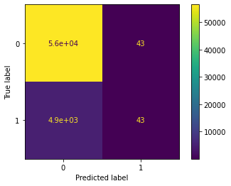

```python
# plot confusion matrix
plot_confusion_matrix(logistic_clf, x_test, y_test)
plt.show()
```

```python
# add accuracy score to results table
results.loc[0] = ['Logistic Regression (Baseline)', 'All application data features', np.round(logistic_train_mean_accuracy_score*100, 2), np.round(logistic_test_score*100, 2), np.round(logistic_train_mean_roc_score*100, 2), np.round(logistic_test_roc_score*100, 2), logistic_grid_search.best_params_]

# show results
results
```

|  | model | Experiment | Train Accuracy | Test Accuracy | Train Area under ROC | Test Area under ROC | Best Parameters |
| --- | --- | --- | --- | --- | --- | --- | --- |
| 0 | Logistic Regression (Baseline) | All application data features | 91.91 | 91.93 | 74.17 | 74.48 | {'logistic__C': 0.1, 'logistic__l1_ratio': 0.6} |

##### Feature Importance

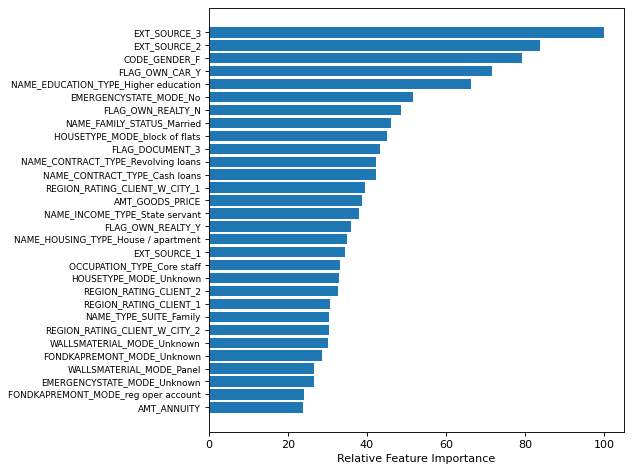

```
There are 39 features that have 0 importance.
```

```python
# plot the feature importance
lr_feature_importance_plot(clf=logistic_clf, names=column_names, n=30)
```

# Phase 2

## Data Prep

### Overview

Throughout this section, the following occurs.

- The POS cash balance, installment payment, and credit card balance files get rolled up to the previous applications file joined by SK_ID_PREV.
- The bureau balance file gets rolled up to the bureau file joined by SK_ID_BUREAU.
- The joined previous application data gets rolled up to the applications file
- The joined bureau data gets rolled up to the applications file

### Previous Applications Workflow

#### POS Cash Balance

```python
# set pos cash pipeline
pos_pipe = Pipeline([
    ('ohe', getDummies()),
    ('aggregater', FeaturesAggregater(grouping_feature = 'SK_ID_PREV', previousDFcolumns = cashBalDF.columns, prefix = 'POS')),
    ('missing data remover', MissingFeatureRemover()),
    ('collinearity remover', CollinearFeatureRemover())
])
```

```python
# aggregate the data
aggcashBalDF = pos_pipe.fit_transform(cashBalDF)
```

```python
# delete objects no longer needed for memory
import gc
gc.enable()
del cashBalDF
gc.collect()
```

```
44
```

#### Credit Card Balance

```python
# get column names
creditCardBalDF_columns = list(creditCardBalDF.columns)
creditCardBalDF_columns.extend(['DPD_MISSED', 'CREDIT_UTILIZED', 'MIN_CREDIT_AMTMISS'])

# set credit card pipeline
credit_card_pipe = Pipeline([
    ('credit_card_features', CreditCardBalanceFeaturesAdder()),
    ('ohe', getDummies()),
    ('aggregater', FeaturesAggregater(grouping_feature = 'SK_ID_PREV', previousDFcolumns = creditCardBalDF_columns, prefix = 'CC')),
    ('missing data remover', MissingFeatureRemover()),
    ('collinearity remover', CollinearFeatureRemover())
])
```

```python
# aggregate the data
aggcreditCardBalDF = credit_card_pipe.fit_transform(creditCardBalDF)
```

```python
# delete objects no longer needed for memory
import gc
gc.enable()
del creditCardBalDF
gc.collect()
```

```
67
```

#### Installment Payments

```python
# get column names
installmentPayDF_columns = list(installmentPayDF.columns)
installmentPayDF_columns.extend(['PAY_IS_LATE', 'AMT_MISSED'])

# set installment pipeline
installment_pipe = Pipeline([
    ('installment_features', InstallmentFeaturesAdder()),
    ('ohe', getDummies()),
    ('aggregater', FeaturesAggregater(grouping_feature = 'SK_ID_PREV', previousDFcolumns = installmentPayDF_columns, prefix = 'INST')),
    ('missing data remover', MissingFeatureRemover()),
    ('collinearity remover', CollinearFeatureRemover())
])
```

```python
# aggregate the data
agginstallmentPayDF = installment_pipe.fit_transform(installmentPayDF)
```

```python
# delete objects no longer needed for memory
import gc
gc.enable()
del installmentPayDF
gc.collect()
```

```
52
```

#### Previous Applications

##### Merge in aggregate data sets

```python
prev_apps_all_df = previousAppDF.merge(aggcashBalDF, how='left', on='SK_ID_PREV')
prev_apps_all_df = prev_apps_all_df.merge(agginstallmentPayDF, how='left', on='SK_ID_PREV')
prev_apps_all_df = prev_apps_all_df.merge(aggcreditCardBalDF, how='left', on='SK_ID_PREV')
```

```python
# this should be true
len(prev_apps_all_df) == len(previousAppDF)
```

```
True
```

```python
# delete objects no longer needed for memory
import gc
gc.enable()
del previousAppDF
gc.collect()
```

```
100
```

##### Aggregate

```python
# get column names
prev_apps_all_df_columns = list(prev_apps_all_df.columns)
prev_apps_all_df_columns.extend(['INTEREST', 'INTEREST_PER_CREDIT', 'CREDIT_SUCCESS', 'INTEREST_RT'])

# set previous app pipeline
previous_app_pipe = Pipeline([
    ('previous_application_features', PreviousApplicationFeaturesAdder()),
    ('ohe', getDummies()),
    ('aggregater', FeaturesAggregater(grouping_feature = 'SK_ID_CURR', previousDFcolumns = prev_apps_all_df_columns, prefix = 'PREV')),
    ('missing data remover', MissingFeatureRemover()),
    ('collinearity remover', CollinearFeatureRemover())
])
```

```python
# aggregate the data
aggprev_apps_all_df = previous_app_pipe.fit_transform(prev_apps_all_df)
```

```python
# delete objects no longer needed for memory
import gc
gc.enable()
del prev_apps_all_df
gc.collect()
```

```
50
```

### Bureau Workflow

- **Step 1:** One hot encode categorical features in bureau balance data for categorical features
- **Step 2:** Aggregate numeric features by calculating min, max, mean, count, and sum for each feature. Aggregate the categorical features by taking the mean, count, and sum.
- **Step 3:** After aggregating, remove columns that have high amounts of missing data and are highly collinear with other columns. This is a great way to reduce the feature space before storing the file.
- **Step 4:** Join the balance data sets to the bureau data separately.
- **Step 5:** For joined bureau datasets: Aggregate numeric features by calculating min, max, mean, count, and sum for each min, max, mean, count, and sum feature. Aggregate the categorical features by taking the mean, count, and sum for each mean, count, and sum feature created previously.
- **Step 6:** After aggregating, remove columns that have high amounts of missing data and are highly collinear with other columns. This is a great way to reduce the feature space before storing the file.
- **Step 7:** Join the aggregated bureau data to the application data by SK_ID_CURR

#### Bureau Balance

```python
# get column names
bureauBalDF_columns = list(bureauBalDF.columns)

# set bureau balance pipeline
bureau_balance_pipe = Pipeline([
    ('ohe', getDummies()),
    ('aggregater', FeaturesAggregater(grouping_feature = 'SK_ID_BUREAU', previousDFcolumns = bureauBalDF_columns, prefix = 'BURBAL')),
    ('missing data remover', MissingFeatureRemover()),
    ('collinearity remover', CollinearFeatureRemover())
])
```

```python
# aggregate the data
aggbureauBalDF = bureau_balance_pipe.fit_transform(bureauBalDF)
```

```python
# delete objects no longer needed for memory
import gc
gc.enable()
del bureauBalDF
gc.collect()
```

```
50
```

#### Bureau

##### Merge in aggregate data set

```python
bureau_all_df = bureauDF.merge(aggbureauBalDF, how='left', on='SK_ID_BUREAU')
```

```python
# this should be true
len(bureau_all_df) == len(bureauDF)
```

```
True
```

```python
# delete objects no longer needed for memory
import gc
gc.enable()
del bureauDF
gc.collect()
```

```
150
```

##### Aggregate

```python
# get column names
bureau_all_df_columns = list(bureau_all_df.columns)

# set bureau pipeline
bureau_pipe = Pipeline([
    ('ohe', getDummies()),
    ('aggregater', FeaturesAggregater(grouping_feature = 'SK_ID_CURR', previousDFcolumns = bureau_all_df_columns, prefix = 'BUR')),
    ('missing data remover', MissingFeatureRemover()),
    ('collinearity remover', CollinearFeatureRemover())
])
```

```python
# aggregate the data
aggbureau_all_df = bureau_pipe.fit_transform(bureau_all_df)
```

```python
# delete objects no longer needed for memory
import gc
gc.enable()
del bureau_all_df
gc.collect()
```

```
50
```

### Applications Workflow

- Step 1: Merge previous aggregated application data and aggregated bureau data to application data by SK_ID_CURR
- Step 2: Add additional loan domain features
- Step 3: Remove features with high amounts of missingness above threshold
- Step 4: Remove collinear features above threshold
- Step 5: Remove zero variance features from final dataset

#### Applications - Train

```python
# merge the previous application and balance data to app data
appTrainDF = appTrainDF.merge(aggprev_apps_all_df, how='left', on='SK_ID_CURR')
appTrainDF = appTrainDF.merge(aggbureau_all_df, how='left', on='SK_ID_CURR')
```

```python
# set application pipeline
app_pipe = Pipeline([
    ('app_features', ApplicationFeaturesAdder()),
    ('missing data remover', MissingFeatureRemover()),
    ('collinearity remover', CollinearFeatureRemover()),
    ('near zero variance remover', NearZeroVarianceFeatureRemover())
])
```

```python
# transform the data
final_appTrainDF = app_pipe.fit_transform(appTrainDF)
```

```python
# print out final shape of data
final_appTrainDF.shape
```

[output not shown]

#### Applications - Test

```python
# merge the previous application and balance data to app data
appTestDF = appTestDF.merge(aggprev_apps_all_df, how='left', on='SK_ID_CURR')
appTestDF = appTestDF.merge(aggbureau_all_df, how='left', on='SK_ID_CURR')
```

```python
# transform the data
final_appTestDF = app_pipe.transform(appTestDF)
```

```python
# print out final shape of data
final_appTestDF.shape
```

[output not shown]

## Additional EDA - Combined Application Dataset

```python
final_appTrainDF.describe() #numerical only features
```

|  | SK_ID_CURR | TARGET | CNT_CHILDREN | AMT_INCOME_TOTAL | AMT_CREDIT | AMT_ANNUITY | REGION_POPULATION_RELATIVE | DAYS_BIRTH | DAYS_EMPLOYED | DAYS_REGISTRATION | DAYS_ID_PUBLISH | FLAG_MOBIL | FLAG_WORK_PHONE | FLAG_CONT_MOBILE | FLAG_PHONE | FLAG_EMAIL | CNT_FAM_MEMBERS | REGION_RATING_CLIENT | HOUR_APPR_PROCESS_START | REG_REGION_NOT_LIVE_REGION | REG_REGION_NOT_WORK_REGION | LIVE_REGION_NOT_WORK_REGION | REG_CITY_NOT_LIVE_CITY | REG_CITY_NOT_WORK_CITY | LIVE_CITY_NOT_WORK_CITY | EXT_SOURCE_1 | EXT_SOURCE_2 | EXT_SOURCE_3 | APARTMENTS_AVG | … |
| --- | --- | --- | --- | --- | --- | --- | --- | --- | --- | --- | --- | --- | --- | --- | --- | --- | --- | --- | --- | --- | --- | --- | --- | --- | --- | --- | --- | --- | --- | --- |
| count | 307511.000000 | 307511.000000 | 307511.000000 | 3.075110e+05 | 3.075110e+05 | 307499.000000 | 307511.000000 | 307511.000000 | 307511.000000 | 307511.000000 | 307511.000000 | 307511.000000 | 307511.000000 | 307511.000000 | 307511.000000 | 307511.000000 | 307509.000000 | 307511.000000 | 307511.000000 | 307511.000000 | 307511.000000 | 307511.000000 | 307511.000000 | 307511.000000 | 307511.000000 | 134133.000000 | 3.068510e+05 | 246546.000000 | 151450.00000 | … |
| mean | 278180.518577 | 0.080729 | 0.417052 | 1.687979e+05 | 5.990260e+05 | 27108.573909 | 0.020868 | -16036.995067 | 63815.045904 | -4986.120328 | -2994.202373 | 0.999997 | 0.199368 | 0.998133 | 0.281066 | 0.056720 | 2.152665 | 2.052463 | 12.063419 | 0.015144 | 0.050769 | 0.040659 | 0.078173 | 0.230454 | 0.179555 | 0.502130 | 5.143927e-01 | 0.510853 | 0.11744 | … |
| std | 102790.175348 | 0.272419 | 0.722121 | 2.371231e+05 | 4.024908e+05 | 14493.737315 | 0.013831 | 4363.988632 | 141275.766519 | 3522.886321 | 1509.450419 | 0.001803 | 0.399526 | 0.043164 | 0.449521 | 0.231307 | 0.910682 | 0.509034 | 3.265832 | 0.122126 | 0.219526 | 0.197499 | 0.268444 | 0.421124 | 0.383817 | 0.211062 | 1.910602e-01 | 0.194844 | 0.10824 | … |
| min | 100002.000000 | 0.000000 | 0.000000 | 2.565000e+04 | 4.500000e+04 | 1615.500000 | 0.000290 | -25229.000000 | -17912.000000 | -24672.000000 | -7197.000000 | 0.000000 | 0.000000 | 0.000000 | 0.000000 | 0.000000 | 1.000000 | 1.000000 | 0.000000 | 0.000000 | 0.000000 | 0.000000 | 0.000000 | 0.000000 | 0.000000 | 0.014568 | 8.173617e-08 | 0.000527 | 0.00000 | … |
| 25% | 189145.500000 | 0.000000 | 0.000000 | 1.125000e+05 | 2.700000e+05 | 16524.000000 | 0.010006 | -19682.000000 | -2760.000000 | -7479.500000 | -4299.000000 | 1.000000 | 0.000000 | 1.000000 | 0.000000 | 0.000000 | 2.000000 | 2.000000 | 10.000000 | 0.000000 | 0.000000 | 0.000000 | 0.000000 | 0.000000 | 0.000000 | 0.334007 | 3.924574e-01 | 0.370650 | 0.05770 | … |
| 50% | 278202.000000 | 0.000000 | 0.000000 | 1.471500e+05 | 5.135310e+05 | 24903.000000 | 0.018850 | -15750.000000 | -1213.000000 | -4504.000000 | -3254.000000 | 1.000000 | 0.000000 | 1.000000 | 0.000000 | 0.000000 | 2.000000 | 2.000000 | 12.000000 | 0.000000 | 0.000000 | 0.000000 | 0.000000 | 0.000000 | 0.000000 | 0.505998 | 5.659614e-01 | 0.535276 | 0.08760 | … |
| 75% | 367142.500000 | 0.000000 | 1.000000 | 2.025000e+05 | 8.086500e+05 | 34596.000000 | 0.028663 | -12413.000000 | -289.000000 | -2010.000000 | -1720.000000 | 1.000000 | 0.000000 | 1.000000 | 1.000000 | 0.000000 | 3.000000 | 2.000000 | 14.000000 | 0.000000 | 0.000000 | 0.000000 | 0.000000 | 0.000000 | 0.000000 | 0.675053 | 6.636171e-01 | 0.669057 | 0.14850 | … |
| max | 456255.000000 | 1.000000 | 19.000000 | 1.170000e+08 | 4.050000e+06 | 258025.500000 | 0.072508 | -7489.000000 | 365243.000000 | 0.000000 | 0.000000 | 1.000000 | 1.000000 | 1.000000 | 1.000000 | 1.000000 | 20.000000 | 3.000000 | 23.000000 | 1.000000 | 1.000000 | 1.000000 | 1.000000 | 1.000000 | 1.000000 | 0.962693 | 8.549997e-01 | 0.896010 | 1.00000 | … |

8 rows × 651 columns

```python
final_appTrainDF.info()
```

```
<class 'pandas.core.frame.DataFrame'>
Int64Index: 307511 entries, 0 to 307510
Columns: 667 entries, SK_ID_CURR to HAS_LIBAILITY
dtypes: float64(612), int64(39), object(16)
memory usage: 1.5+ GB
```

#### Missing Data

```python
percent = (final_appTrainDF.isnull().sum()/final_appTrainDF.isnull().count()*100).sort_values(ascending = False).round(2)
sum_missing = final_appTrainDF.isna().sum().sort_values(ascending = False)
missing_application_train_data  = pd.concat([percent, sum_missing], axis=1, keys=['Percent', "Train Missing Count"])
missing_application_train_data.head(20)
```

|  | Percent | Train Missing Count |
| --- | --- | --- |
| LANDAREA_AVG | 59.38 | 182590 |
| BASEMENTAREA_AVG | 58.52 | 179943 |
| EXT_SOURCE_1 | 56.38 | 173378 |
| NONLIVINGAREA_AVG | 55.18 | 169682 |
| ELEVATORS_AVG | 53.30 | 163891 |
| WALLSMATERIAL_MODE | 50.84 | 156341 |
| APARTMENTS_AVG | 50.75 | 156061 |
| ENTRANCES_AVG | 50.35 | 154828 |
| HOUSETYPE_MODE | 50.18 | 154297 |
| FLOORSMAX_AVG | 49.76 | 153020 |
| YEARS_BEGINEXPLUATATION_AVG | 48.78 | 150007 |
| EMERGENCYSTATE_MODE | 47.40 | 145755 |
| BUR_AMT_CREDIT_MAX_OVERDUE_min | 40.20 | 123625 |
| OCCUPATION_TYPE | 31.35 | 96391 |
| BUR_DAYS_ENDDATE_FACT_min | 25.09 | 77156 |
| BUR_DAYS_ENDDATE_FACT_max | 25.09 | 77156 |
| BUR_DAYS_ENDDATE_FACT_mean | 25.09 | 77156 |
| BUR_AMT_CREDIT_SUM_LIMIT_min | 21.16 | 65069 |
| BUR_AMT_CREDIT_SUM_LIMIT_max | 21.16 | 65069 |
| BUR_AMT_CREDIT_SUM_LIMIT_mean | 21.16 | 65069 |

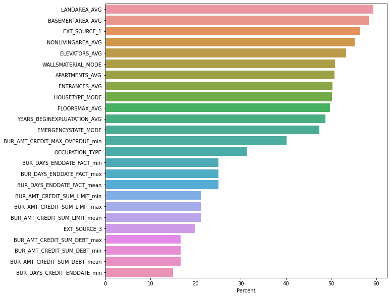

```python
plt.figure(figsize=(10,10))
sns.barplot(y=missing_application_train_data.head(25).index, x=missing_application_train_data.head(25).Percent)
```

#### Correlation

##### Top 20 Features Against TARGET - Positive & Negative

```python
correlation_all = final_appTrainDF.sample(10000).corr()['TARGET'].sort_values()

print('\nMost Negative Correlations with TARGET - Top 20:')
print(correlation_all.head(20))
```

```
Most Negative Correlations with TARGET - Top 20:
EXT_SOURCE_3                                        -0.199442
EXT_SOURCE_2                                        -0.173268
EXT_SOURCE_1                                        -0.146112
PREV_DAYS_FIRST_DRAWING_mean                        -0.075793
PREV_DAYS_FIRST_DRAWING_min                         -0.074786
PREV_NAME_CONTRACT_STATUS_Approved_mean             -0.063152
PREV_INST_NUM_INSTALMENT_VERSION_min_mean           -0.060019
DAYS_EMPLOYED                                       -0.056582
PREV_DAYS_FIRST_DUE_max                             -0.051637
PREV_PRODUCT_COMBINATION_Cash X-Sell: low_mean      -0.051410
PREV_POS_MONTHS_BALANCE_count_sum                   -0.049505
PREV_POS_MONTHS_BALANCE_count_max                   -0.044412
PREV_POS_NAME_CONTRACT_STATUS_Active_mean_max       -0.042688
PREV_NAME_YIELD_GROUP_low_normal_mean               -0.042551
PREV_INTEREST_RT_mean                               -0.041364
PREV_INST_NUM_INSTALMENT_VERSION_sum_sum            -0.040522
PREV_INST_PAY_IS_LATE_mean_sum                      -0.040122
FLAG_DOCUMENT_6                                     -0.040103
PREV_NAME_PAYMENT_TYPE_Cash through the bank_mean   -0.038367
PREV_INTEREST_RT_sum                                -0.037419
Name: TARGET, dtype: float64
```

##### Heat Map - Top Features Against TARGET

```python
correlation_target = final_appTrainDF.sample(10000).corr()['TARGET'].sort_values()

top_correlation_features=[]
for i in correlation_target.head(6).keys().tolist():
    top_correlation_features.append(i)

for i in correlation_target.tail(6).keys().tolist():
    top_correlation_features.append(i)
```

```python
top_correlation_features
```

```
['EXT_SOURCE_2',
 'EXT_SOURCE_3',
 'EXT_SOURCE_1',
 'PREV_RATE_DOWN_PAYMENT_max',
 'PREV_INST_PAY_IS_LATE_mean_sum',
 'PREV_RATE_DOWN_PAYMENT_sum',
 'BUR_CREDIT_TYPE_Loan for purchase of shares (margin lending)_sum',
 'BUR_CREDIT_TYPE_Loan for the purchase of equipment_mean',
 'BUR_CREDIT_TYPE_Mobile operator loan_mean',
 'BUR_CREDIT_TYPE_Mobile operator loan_sum',
 'BUR_CREDIT_TYPE_Real estate loan_mean',
 'BUR_CREDIT_TYPE_Real estate loan_sum']
```

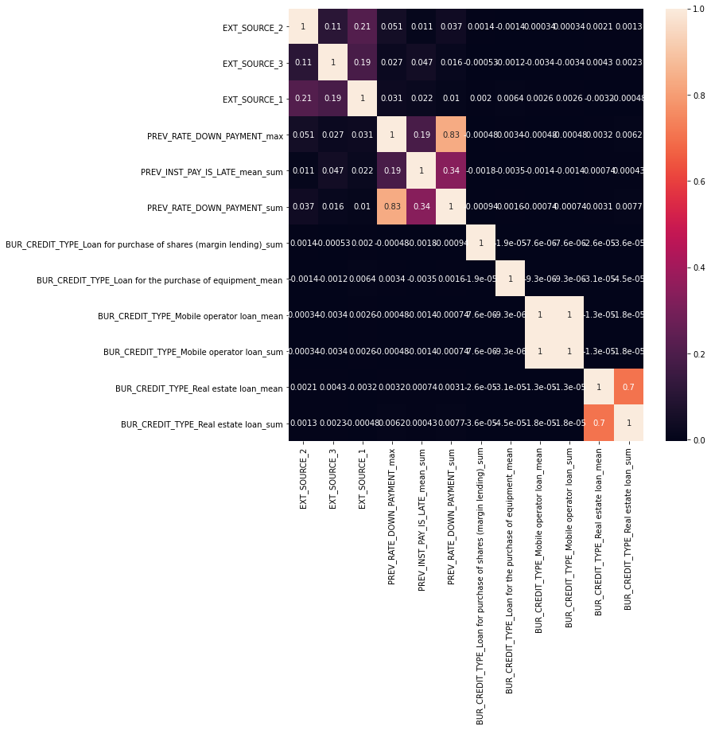

```python
# Correlation Heat Map for Some Top Features
fig, ax = plt.subplots(figsize=(10,10))
sns.heatmap(
    final_appTrainDF.loc[:, top_correlation_features].corr(),
    annot=True
)
```

#### Value Distribution in TARGET column

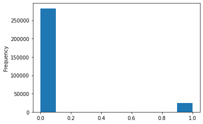

```python
final_appTrainDF['TARGET'].astype(int).plot.hist();
```

## Modeling

### Split data

```python
# assign the input and response features
X = final_appTrainDF.drop(['SK_ID_CURR', 'TARGET'], axis = 1) # features
y = final_appTrainDF['TARGET'] # label
```

```python
# split data such that 80% in training and 20% in test
x_train, x_test, y_train, y_test = train_test_split(X, y, stratify=y, test_size=.2, random_state=42)
```

### Generate a smaller sample for tuning

```python
# split data such that 10% is used for tuning, other 90% used for cross fold validation with best hyperparameters
x_sample_10, x_sample_90, y_sample_10, y_sample_90 = train_test_split(x_train, y_train, stratify=y_train, test_size=.9, random_state=42)
```

```python
x_sample_10.shape
```

```
(24600, 665)
```

### Pipeline

```python
categorical_features = final_appTrainDF.select_dtypes(include='object').columns.tolist()
numerical_features = final_appTrainDF.select_dtypes(exclude='object').columns.tolist()
numerical_features.remove('SK_ID_CURR')
numerical_features.remove('TARGET')
```

#### Set the data pipeline

```python
# create pipeline for numeric features
num_pipeline = Pipeline([
        ('imputer', SimpleImputer(strategy="median")),
        ('std_scaler', StandardScaler()),
    ])

# create pipeline for categorical features
cat_pipeline = Pipeline([
        ('imputer', SimpleImputer(strategy='constant', fill_value="Unknown")),
        ('ohe', OneHotEncoder(sparse=False, handle_unknown="ignore"))
    ])

# specify the column transformer for numeric and categorical features
data_pipeline = ColumnTransformer(
    [("num_pipeline", num_pipeline, numerical_features),
    ("cat_pipeline", cat_pipeline, categorical_features)],
    remainder='passthrough')
```

### Hyperparameter Tuning

#### Candidate parameters

```python
# set logistic parameter grid
logistic_params= {'logistic__C': (100, 10, 1, 0.1, 0.01),
                  'logistic__l1_ratio': (0, .1, .2, .3, .4, .5, .6, .7, .8, .9, 1.),
                 }

# set xgboost parameter grid
xgb_params = {'xgb__n_estimators': [100, 300],
              'xgb__learning_rate': [0.01, 0.1],
              'xgb__max_depth': range(3, 10),
              'xgb__colsample_bytree': [i/10.0 for i in range(1, 3)]
             }

# set lightgbm parameter grid
lgbm_params = {'lgbm__boosting_type': ['goss','dart'],
               'lgbm__n_estimators': [3000, 5000, 7000],
               'lgbm__learning_rate': [0.005, 0.001, 0.05, 0.01],
               'lgbm__max_depth': [2, 6, 10],
               'lgbm__colsample_bytree': [0.1, 0.3, 0.5]
             }
```

### Regularized Logistic Regression

```python
# generate the pipeline
logistic_pipeline = Pipeline([
("preparation", data_pipeline),
("zv", VarianceThreshold()),
("logistic", LogisticRegression(penalty='elasticnet', solver='saga', random_state=42))
])

# set up cross validation grid search
logistic_grid_search = GridSearchCV(logistic_pipeline,
                                    param_grid=logistic_params,
                                    scoring='roc_auc',
                                    cv=5,
                                    n_jobs=20,
                                    verbose=True)

# grid search on training data
logistic_grid_search.fit(x_sample_10, y_sample_10)
```

```
Fitting 5 folds for each of 55 candidates, totalling 275 fits
```

```
[Parallel(n_jobs=20)]: Using backend LokyBackend with 20 concurrent workers.
[Parallel(n_jobs=20)]: Done  10 tasks      | elapsed:   35.9s
[Parallel(n_jobs=20)]: Done 160 tasks      | elapsed:  4.0min
[Parallel(n_jobs=20)]: Done 275 out of 275 | elapsed:  6.8min finished
```

```
GridSearchCV(cv=5, error_score=nan,
             estimator=Pipeline(memory=None,
                                steps=[('preparation',
                                        ColumnTransformer(n_jobs=None,
                                                          remainder='passthrough',
                                                          sparse_threshold=0.3,
                                                          transformer_weights=None,
                                                          transformers=[('num_pipeline',
                                                                         Pipeline(memory=None,
                                                                                  steps=[('imputer',
                                                                                          SimpleImputer(add_indicator=False,
                                                                                                        copy=True,
                                                                                                        fill_value=None,
                                                                                                        missing_values=nan,
                                                                                                        strategy='media...
                                                           multi_class='auto',
                                                           n_jobs=None,
                                                           penalty='elasticnet',
                                                           random_state=42,
                                                           solver='saga',
                                                           tol=0.0001,
                                                           verbose=0,
                                                           warm_start=False))],
                                verbose=False),
             iid='deprecated', n_jobs=20,
             param_grid={'logistic__C': (100, 10, 1, 0.1, 0.01),
                         'logistic__l1_ratio': (0, 0.1, 0.2, 0.3, 0.4, 0.5, 0.6,
                                                0.7, 0.8, 0.9, 1.0)},
             pre_dispatch='2*n_jobs', refit=True, return_train_score=False,
             scoring='roc_auc', verbose=True)
```

```python
# print grid search results
pd.concat([pd.DataFrame(logistic_grid_search.cv_results_["params"]),pd.DataFrame(logistic_grid_search.cv_results_["mean_test_score"], columns=["roc_auc"])],axis=1).sort_values(by='roc_auc', ascending=False)
```

|  | logistic__C | logistic__l1_ratio | roc_auc |
| --- | --- | --- | --- |
| 46 | 0.01 | 0.2 | 0.755720 |
| 47 | 0.01 | 0.3 | 0.755274 |
| 48 | 0.01 | 0.4 | 0.753962 |
| 45 | 0.01 | 0.1 | 0.753481 |
| 43 | 0.10 | 1.0 | 0.752968 |
| 42 | 0.10 | 0.9 | 0.752533 |
| 49 | 0.01 | 0.5 | 0.752250 |
| 41 | 0.10 | 0.8 | 0.752019 |
| 40 | 0.10 | 0.7 | 0.751401 |
| 39 | 0.10 | 0.6 | 0.750799 |
| 38 | 0.10 | 0.5 | 0.750137 |
| 50 | 0.01 | 0.6 | 0.749834 |
| 37 | 0.10 | 0.4 | 0.749489 |
| 36 | 0.10 | 0.3 | 0.748741 |
| 35 | 0.10 | 0.2 | 0.747898 |
| 44 | 0.01 | 0.0 | 0.747725 |
| 51 | 0.01 | 0.7 | 0.747133 |
| 34 | 0.10 | 0.1 | 0.747044 |
| 32 | 1.00 | 1.0 | 0.746858 |
| 31 | 1.00 | 0.9 | 0.746767 |
| 30 | 1.00 | 0.8 | 0.746683 |
| 29 | 1.00 | 0.7 | 0.746594 |
| 28 | 1.00 | 0.6 | 0.746506 |
| 27 | 1.00 | 0.5 | 0.746427 |
| 26 | 1.00 | 0.4 | 0.746342 |
| 25 | 1.00 | 0.3 | 0.746251 |
| 33 | 0.10 | 0.0 | 0.746190 |
| 24 | 1.00 | 0.2 | 0.746162 |
| 23 | 1.00 | 0.1 | 0.746074 |
| 21 | 10.00 | 1.0 | 0.746052 |
| 20 | 10.00 | 0.9 | 0.746040 |
| 19 | 10.00 | 0.8 | 0.746029 |
| 18 | 10.00 | 0.7 | 0.746018 |
| 17 | 10.00 | 0.6 | 0.746006 |
| 16 | 10.00 | 0.5 | 0.745995 |
| 15 | 10.00 | 0.4 | 0.745988 |
| 14 | 10.00 | 0.3 | 0.745980 |
| 22 | 1.00 | 0.0 | 0.745975 |
| 13 | 10.00 | 0.2 | 0.745972 |
| 12 | 10.00 | 0.1 | 0.745964 |
| 10 | 100.00 | 1.0 | 0.745961 |
| 9 | 100.00 | 0.9 | 0.745960 |
| 8 | 100.00 | 0.8 | 0.745958 |
| 7 | 100.00 | 0.7 | 0.745958 |
| 6 | 100.00 | 0.6 | 0.745956 |
| 5 | 100.00 | 0.5 | 0.745956 |
| 11 | 10.00 | 0.0 | 0.745955 |
| 4 | 100.00 | 0.4 | 0.745955 |
| 3 | 100.00 | 0.3 | 0.745954 |
| 2 | 100.00 | 0.2 | 0.745954 |
| 1 | 100.00 | 0.1 | 0.745952 |
| 0 | 100.00 | 0.0 | 0.745952 |
| 52 | 0.01 | 0.8 | 0.744683 |
| 53 | 0.01 | 0.9 | 0.742311 |
| 54 | 0.01 | 1.0 | 0.740016 |

```python
# print the best parameters
logistic_grid_search.best_params_
```

```
{'logistic__C': 0.01, 'logistic__l1_ratio': 0.2}
```

#### Cross Validation Evalutation

```python
# perform 5 fold cv with best hyperparameters
scoring = {'accuracy': 'accuracy',
           'roc_auc': 'roc_auc',
          }

cv_results = cross_validate(logistic_grid_search.best_estimator_,
                          x_sample_90, y_sample_90,
                          scoring=scoring,
                          cv=5,
                          n_jobs=2)
```

```python
# print results of cross validation
pd.DataFrame(
    {'test_accuracy': cv_results['test_accuracy'],
     'test_roc_auc': cv_results['test_roc_auc'],
    })
```

|  | test_accuracy | test_roc_auc |
| --- | --- | --- |
| 0 | 0.919335 | 0.765085 |
| 1 | 0.919403 | 0.771059 |
| 2 | 0.919200 | 0.763233 |
| 3 | 0.919446 | 0.770164 |
| 4 | 0.919017 | 0.758298 |

```python
# calculate mean out of sample cv train roc score
logistic_train_mean_roc_score = np.mean(cv_results['test_roc_auc'])

# print the mean out of sample cv train roc score
logistic_train_mean_roc_score
```

```
0.7655677302022866
```

```python
# calculate mean out of sample cv train accuracy score
logistic_train_mean_accuracy_score = np.mean(cv_results['test_accuracy'])

# print the mean out of sample cv train accuracy score
logistic_train_mean_accuracy_score
```

```
0.9192802423713895
```

### XGBoost

```python
# generate the pipeline
xgb_pipeline = Pipeline([
    ("preparation", data_pipeline),
    ("zv", VarianceThreshold()),
    ("xgb", XGBClassifier(random_state=42))
])

# set up cross validation grid search
xgb_grid_search = GridSearchCV(xgb_pipeline,
                                    param_grid=xgb_params,
                                    scoring='roc_auc',
                                    cv=5,
                                    n_jobs=20,
                                    verbose=True)

# grid search on training data
xgb_grid_search.fit(x_sample_10, y_sample_10)
```

```
Fitting 5 folds for each of 56 candidates, totalling 280 fits
```

```
[Parallel(n_jobs=20)]: Using backend LokyBackend with 20 concurrent workers.
[Parallel(n_jobs=20)]: Done  10 tasks      | elapsed:   19.8s
[Parallel(n_jobs=20)]: Done 160 tasks      | elapsed:  4.6min
[Parallel(n_jobs=20)]: Done 280 out of 280 | elapsed:  9.9min finished
```

```
GridSearchCV(cv=5, error_score=nan,
             estimator=Pipeline(memory=None,
                                steps=[('preparation',
                                        ColumnTransformer(n_jobs=None,
                                                          remainder='passthrough',
                                                          sparse_threshold=0.3,
                                                          transformer_weights=None,
                                                          transformers=[('num_pipeline',
                                                                         Pipeline(memory=None,
                                                                                  steps=[('imputer',
                                                                                          SimpleImputer(add_indicator=False,
                                                                                                        copy=True,
                                                                                                        fill_value=None,
                                                                                                        missing_values=nan,
                                                                                                        strategy='media...
                                                      reg_alpha=0, reg_lambda=1,
                                                      scale_pos_weight=1,
                                                      seed=None, silent=None,
                                                      subsample=1,
                                                      verbosity=1))],
                                verbose=False),
             iid='deprecated', n_jobs=20,
             param_grid={'xgb__colsample_bytree': [0.1, 0.2],
                         'xgb__learning_rate': [0.01, 0.1],
                         'xgb__max_depth': range(3, 10),
                         'xgb__n_estimators': [100, 300]},
             pre_dispatch='2*n_jobs', refit=True, return_train_score=False,
             scoring='roc_auc', verbose=True)
```

```python
# print grid search results
pd.concat([pd.DataFrame(xgb_grid_search.cv_results_["params"]),pd.DataFrame(xgb_grid_search.cv_results_["mean_test_score"], columns=["roc_auc"])],axis=1).sort_values(by='roc_auc', ascending=False)
```

|  | xgb__colsample_bytree | xgb__learning_rate | xgb__max_depth | xgb__n_estimators | roc_auc |
| --- | --- | --- | --- | --- | --- |
| 15 | 0.1 | 0.10 | 3 | 300 | 0.759102 |
| 43 | 0.2 | 0.10 | 3 | 300 | 0.758156 |
| 44 | 0.2 | 0.10 | 4 | 100 | 0.757679 |
| 46 | 0.2 | 0.10 | 5 | 100 | 0.756906 |
| 42 | 0.2 | 0.10 | 3 | 100 | 0.756423 |
| 18 | 0.1 | 0.10 | 5 | 100 | 0.755218 |
| 16 | 0.1 | 0.10 | 4 | 100 | 0.755082 |
| 14 | 0.1 | 0.10 | 3 | 100 | 0.755011 |
| 17 | 0.1 | 0.10 | 4 | 300 | 0.754247 |
| 48 | 0.2 | 0.10 | 6 | 100 | 0.754199 |
| 45 | 0.2 | 0.10 | 4 | 300 | 0.753220 |
| 47 | 0.2 | 0.10 | 5 | 300 | 0.751825 |
| 50 | 0.2 | 0.10 | 7 | 100 | 0.751643 |
| 19 | 0.1 | 0.10 | 5 | 300 | 0.750229 |
| 22 | 0.1 | 0.10 | 7 | 100 | 0.748909 |
| 20 | 0.1 | 0.10 | 6 | 100 | 0.747577 |
| 39 | 0.2 | 0.01 | 8 | 300 | 0.747234 |
| 51 | 0.2 | 0.10 | 7 | 300 | 0.746857 |
| 52 | 0.2 | 0.10 | 8 | 100 | 0.746473 |
| 41 | 0.2 | 0.01 | 9 | 300 | 0.746386 |
| 37 | 0.2 | 0.01 | 7 | 300 | 0.746309 |
| 35 | 0.2 | 0.01 | 6 | 300 | 0.745744 |
| 33 | 0.2 | 0.01 | 5 | 300 | 0.745278 |
| 23 | 0.1 | 0.10 | 7 | 300 | 0.743862 |
| 54 | 0.2 | 0.10 | 9 | 100 | 0.743710 |
| 49 | 0.2 | 0.10 | 6 | 300 | 0.742879 |
| 21 | 0.1 | 0.10 | 6 | 300 | 0.742815 |
| 31 | 0.2 | 0.01 | 4 | 300 | 0.742270 |
| 27 | 0.1 | 0.10 | 9 | 300 | 0.741630 |
| 55 | 0.2 | 0.10 | 9 | 300 | 0.740470 |
| 53 | 0.2 | 0.10 | 8 | 300 | 0.739964 |
| 25 | 0.1 | 0.10 | 8 | 300 | 0.739950 |
| 24 | 0.1 | 0.10 | 8 | 100 | 0.739748 |
| 13 | 0.1 | 0.01 | 9 | 300 | 0.738897 |
| 11 | 0.1 | 0.01 | 8 | 300 | 0.738214 |
| 7 | 0.1 | 0.01 | 6 | 300 | 0.738003 |
| 29 | 0.2 | 0.01 | 3 | 300 | 0.737713 |
| 9 | 0.1 | 0.01 | 7 | 300 | 0.737478 |
| 5 | 0.1 | 0.01 | 5 | 300 | 0.736893 |
| 3 | 0.1 | 0.01 | 4 | 300 | 0.735560 |
| 26 | 0.1 | 0.10 | 9 | 100 | 0.733003 |
| 1 | 0.1 | 0.01 | 3 | 300 | 0.732329 |
| 36 | 0.2 | 0.01 | 7 | 100 | 0.731216 |
| 38 | 0.2 | 0.01 | 8 | 100 | 0.731164 |
| 34 | 0.2 | 0.01 | 6 | 100 | 0.730644 |
| 40 | 0.2 | 0.01 | 9 | 100 | 0.729786 |
| 32 | 0.2 | 0.01 | 5 | 100 | 0.729668 |
| 30 | 0.2 | 0.01 | 4 | 100 | 0.728660 |
| 28 | 0.2 | 0.01 | 3 | 100 | 0.724494 |
| 8 | 0.1 | 0.01 | 7 | 100 | 0.724386 |
| 6 | 0.1 | 0.01 | 6 | 100 | 0.724125 |
| 2 | 0.1 | 0.01 | 4 | 100 | 0.723827 |
| 4 | 0.1 | 0.01 | 5 | 100 | 0.723328 |
| 10 | 0.1 | 0.01 | 8 | 100 | 0.722819 |
| 12 | 0.1 | 0.01 | 9 | 100 | 0.722654 |
| 0 | 0.1 | 0.01 | 3 | 100 | 0.721657 |

```python
# print the best parameters
xgb_grid_search.best_params_
```

```
{'xgb__colsample_bytree': 0.1,
 'xgb__learning_rate': 0.1,
 'xgb__max_depth': 3,
 'xgb__n_estimators': 300}
```

##### Cross Validation Evaluation

```python
# perform 5 fold cv with best hyperparameters
scoring = {'accuracy': 'accuracy',
           'roc_auc': 'roc_auc',
          }

#### Cross Validation Evaluation
cv_results = cross_validate(xgb_grid_search.best_estimator_,
                          x_sample_90, y_sample_90,
                          scoring=scoring,
                          cv=5,
                          n_jobs=2)
```

```python
# print results of cross validation
pd.DataFrame(
    {'test_accuracy': cv_results['test_accuracy'],
     'test_roc_auc': cv_results['test_roc_auc'],
    })
```

|  | test_accuracy | test_roc_auc |
| --- | --- | --- |
| 0 | 0.920058 | 0.784876 |
| 1 | 0.919967 | 0.783858 |
| 2 | 0.919629 | 0.782041 |
| 3 | 0.919627 | 0.787148 |
| 4 | 0.919875 | 0.775503 |

```python
# calculate mean out of sample cv train roc score
xgb_train_mean_roc_score = np.mean(cv_results['test_roc_auc'])

# print the mean out of sample cv train roc score
xgb_train_mean_roc_score
```

```
0.7826850815579223
```

```python
# calculate mean out of sample cv train accuracy score
xgb_train_mean_accuracy_score = np.mean(cv_results['test_accuracy'])

# print the mean out of sample cv train accuracy score
xgb_train_mean_accuracy_score
```

```
0.9198312610192385
```

### XGBoost w/ PCA (95% of variance)

```python
# generate the pipeline
xgb_pca_pipeline = Pipeline([
    ("preparation", data_pipeline),
    ("pca", PCA(0.95)),
    ("xgb", XGBClassifier(random_state=42))
])

# set up cross validation grid search
xgb_pca_grid_search = GridSearchCV(xgb_pca_pipeline,
                                    param_grid=xgb_params,
                                    scoring='roc_auc',
                                    cv=5,
                                    n_jobs=20,
                                    verbose=True)

# grid search on training data
xgb_pca_grid_search.fit(x_sample_10, y_sample_10)
```

```
Fitting 5 folds for each of 56 candidates, totalling 280 fits
```

```
[Parallel(n_jobs=20)]: Using backend LokyBackend with 20 concurrent workers.
[Parallel(n_jobs=20)]: Done  10 tasks      | elapsed:   25.1s
[Parallel(n_jobs=20)]: Done 160 tasks      | elapsed:  5.0min
[Parallel(n_jobs=20)]: Done 280 out of 280 | elapsed: 10.8min finished
```

```
GridSearchCV(cv=5, error_score=nan,
             estimator=Pipeline(memory=None,
                                steps=[('preparation',
                                        ColumnTransformer(n_jobs=None,
                                                          remainder='passthrough',
                                                          sparse_threshold=0.3,
                                                          transformer_weights=None,
                                                          transformers=[('num_pipeline',
                                                                         Pipeline(memory=None,
                                                                                  steps=[('imputer',
                                                                                          SimpleImputer(add_indicator=False,
                                                                                                        copy=True,
                                                                                                        fill_value=None,
                                                                                                        missing_values=nan,
                                                                                                        strategy='media...
                                                      reg_alpha=0, reg_lambda=1,
                                                      scale_pos_weight=1,
                                                      seed=None, silent=None,
                                                      subsample=1,
                                                      verbosity=1))],
                                verbose=False),
             iid='deprecated', n_jobs=20,
             param_grid={'xgb__colsample_bytree': [0.1, 0.2],
                         'xgb__learning_rate': [0.01, 0.1],
                         'xgb__max_depth': range(3, 10),
                         'xgb__n_estimators': [100, 300]},
             pre_dispatch='2*n_jobs', refit=True, return_train_score=False,
             scoring='roc_auc', verbose=True)
```

```python
# print grid search results
pd.concat([pd.DataFrame(xgb_pca_grid_search.cv_results_["params"]),pd.DataFrame(xgb_pca_grid_search.cv_results_["mean_test_score"], columns=["roc_auc"])],axis=1).sort_values(by='roc_auc', ascending=False)
```

|  | xgb__colsample_bytree | xgb__learning_rate | xgb__max_depth | xgb__n_estimators | roc_auc |
| --- | --- | --- | --- | --- | --- |
| 43 | 0.2 | 0.10 | 3 | 300 | 0.720959 |
| 15 | 0.1 | 0.10 | 3 | 300 | 0.719899 |
| 17 | 0.1 | 0.10 | 4 | 300 | 0.714445 |
| 45 | 0.2 | 0.10 | 4 | 300 | 0.712822 |
| 44 | 0.2 | 0.10 | 4 | 100 | 0.712555 |
| 42 | 0.2 | 0.10 | 3 | 100 | 0.710963 |
| 16 | 0.1 | 0.10 | 4 | 100 | 0.710833 |
| 46 | 0.2 | 0.10 | 5 | 100 | 0.708498 |
| 53 | 0.2 | 0.10 | 8 | 300 | 0.708189 |
| 18 | 0.1 | 0.10 | 5 | 100 | 0.708030 |
| 14 | 0.1 | 0.10 | 3 | 100 | 0.706815 |
| 55 | 0.2 | 0.10 | 9 | 300 | 0.705619 |
| 48 | 0.2 | 0.10 | 6 | 100 | 0.704946 |
| 49 | 0.2 | 0.10 | 6 | 300 | 0.703973 |
| 19 | 0.1 | 0.10 | 5 | 300 | 0.703971 |
| 35 | 0.2 | 0.01 | 6 | 300 | 0.702944 |
| 47 | 0.2 | 0.10 | 5 | 300 | 0.702467 |
| 37 | 0.2 | 0.01 | 7 | 300 | 0.702387 |
| 39 | 0.2 | 0.01 | 8 | 300 | 0.702255 |
| 27 | 0.1 | 0.10 | 9 | 300 | 0.701492 |
| 51 | 0.2 | 0.10 | 7 | 300 | 0.701193 |
| 25 | 0.1 | 0.10 | 8 | 300 | 0.700442 |
| 41 | 0.2 | 0.01 | 9 | 300 | 0.699583 |
| 33 | 0.2 | 0.01 | 5 | 300 | 0.699369 |
| 23 | 0.1 | 0.10 | 7 | 300 | 0.699353 |
| 9 | 0.1 | 0.01 | 7 | 300 | 0.698568 |
| 21 | 0.1 | 0.10 | 6 | 300 | 0.698433 |
| 7 | 0.1 | 0.01 | 6 | 300 | 0.698040 |
| 20 | 0.1 | 0.10 | 6 | 100 | 0.696844 |
| 11 | 0.1 | 0.01 | 8 | 300 | 0.695890 |
| 52 | 0.2 | 0.10 | 8 | 100 | 0.695544 |
| 31 | 0.2 | 0.01 | 4 | 300 | 0.695222 |
| 5 | 0.1 | 0.01 | 5 | 300 | 0.693881 |
| 50 | 0.2 | 0.10 | 7 | 100 | 0.692366 |
| 3 | 0.1 | 0.01 | 4 | 300 | 0.692282 |
| 13 | 0.1 | 0.01 | 9 | 300 | 0.690299 |
| 22 | 0.1 | 0.10 | 7 | 100 | 0.689795 |
| 54 | 0.2 | 0.10 | 9 | 100 | 0.688903 |
| 29 | 0.2 | 0.01 | 3 | 300 | 0.686995 |
| 1 | 0.1 | 0.01 | 3 | 300 | 0.686535 |
| 24 | 0.1 | 0.10 | 8 | 100 | 0.683986 |
| 26 | 0.1 | 0.10 | 9 | 100 | 0.681109 |
| 2 | 0.1 | 0.01 | 4 | 100 | 0.672016 |
| 32 | 0.2 | 0.01 | 5 | 100 | 0.671635 |
| 34 | 0.2 | 0.01 | 6 | 100 | 0.671558 |
| 6 | 0.1 | 0.01 | 6 | 100 | 0.671149 |
| 30 | 0.2 | 0.01 | 4 | 100 | 0.670937 |
| 0 | 0.1 | 0.01 | 3 | 100 | 0.670718 |
| 36 | 0.2 | 0.01 | 7 | 100 | 0.670511 |
| 4 | 0.1 | 0.01 | 5 | 100 | 0.670429 |
| 38 | 0.2 | 0.01 | 8 | 100 | 0.669308 |
| 40 | 0.2 | 0.01 | 9 | 100 | 0.669264 |
| 8 | 0.1 | 0.01 | 7 | 100 | 0.669211 |
| 28 | 0.2 | 0.01 | 3 | 100 | 0.668304 |
| 10 | 0.1 | 0.01 | 8 | 100 | 0.663712 |
| 12 | 0.1 | 0.01 | 9 | 100 | 0.657982 |

```python
# print the best parameters
xgb_pca_grid_search.best_params_
```

```
{'xgb__colsample_bytree': 0.2,
 'xgb__learning_rate': 0.1,
 'xgb__max_depth': 3,
 'xgb__n_estimators': 300}
```

##### Cross Validation Evaluation

```python
# perform 5 fold cv with best hyperparameters
scoring = {'accuracy': 'accuracy',
           'roc_auc': 'roc_auc',
          }

#### Cross Validation Evaluation
cv_results = cross_validate(xgb_pca_grid_search.best_estimator_,
                          x_sample_90, y_sample_90,
                          scoring=scoring,
                          cv=5,
                          n_jobs=2)
```

```python
# print results of cross validation
pd.DataFrame(
    {'test_accuracy': cv_results['test_accuracy'],
     'test_roc_auc': cv_results['test_roc_auc'],
    })
```

|  | test_accuracy | test_roc_auc |
| --- | --- | --- |
| 0 | 0.919200 | 0.751588 |
| 1 | 0.919313 | 0.755783 |
| 2 | 0.919358 | 0.751716 |
| 3 | 0.919266 | 0.756787 |
| 4 | 0.919469 | 0.747289 |

```python
# calculate mean out of sample cv train roc score
xgb_pca_train_mean_roc_score = np.mean(cv_results['test_roc_auc'])

# print the mean out of sample cv train roc score
xgb_pca_train_mean_roc_score
```

```
0.7526326213551788
```

```python
# calculate mean out of sample cv train accuracy score
xgb_pca_train_mean_accuracy_score = np.mean(cv_results['test_accuracy'])

# print the mean out of sample cv train accuracy score
xgb_pca_train_mean_accuracy_score
```

```
0.9193208921658729
```

### XGBoost /w Feature Selection

```python
# generate the pipeline
xgb_fs_pipeline = Pipeline([
    ("preparation", data_pipeline),
    ("zv", VarianceThreshold()),
    ("feature_selection", SelectFromModel(xgb_grid_search.best_estimator_.named_steps['xgb'])),
    ("xgb", XGBClassifier(random_state=42))
])

# set up cross validation grid search
xgb_fs_grid_search = GridSearchCV(xgb_fs_pipeline,
                                    param_grid=xgb_params,
                                    scoring='roc_auc',
                                    cv=5,
                                    n_jobs=20,
                                    verbose=True)

# grid search on training data
xgb_fs_grid_search.fit(x_sample_10, y_sample_10)
```

```
Fitting 5 folds for each of 56 candidates, totalling 280 fits
```

```
[Parallel(n_jobs=20)]: Using backend LokyBackend with 20 concurrent workers.
[Parallel(n_jobs=20)]: Done  10 tasks      | elapsed:   46.4s
[Parallel(n_jobs=20)]: Done 160 tasks      | elapsed:  7.4min
[Parallel(n_jobs=20)]: Done 280 out of 280 | elapsed: 13.8min finished
```

```
GridSearchCV(cv=5, error_score=nan,
             estimator=Pipeline(memory=None,
                                steps=[('preparation',
                                        ColumnTransformer(n_jobs=None,
                                                          remainder='passthrough',
                                                          sparse_threshold=0.3,
                                                          transformer_weights=None,
                                                          transformers=[('num_pipeline',
                                                                         Pipeline(memory=None,
                                                                                  steps=[('imputer',
                                                                                          SimpleImputer(add_indicator=False,
                                                                                                        copy=True,
                                                                                                        fill_value=None,
                                                                                                        missing_values=nan,
                                                                                                        strategy='media...
                                                      reg_alpha=0, reg_lambda=1,
                                                      scale_pos_weight=1,
                                                      seed=None, silent=None,
                                                      subsample=1,
                                                      verbosity=1))],
                                verbose=False),
             iid='deprecated', n_jobs=20,
             param_grid={'xgb__colsample_bytree': [0.1, 0.2],
                         'xgb__learning_rate': [0.01, 0.1],
                         'xgb__max_depth': range(3, 10),
                         'xgb__n_estimators': [100, 300]},
             pre_dispatch='2*n_jobs', refit=True, return_train_score=False,
             scoring='roc_auc', verbose=True)
```

```python
# print grid search results
pd.concat([pd.DataFrame(xgb_fs_grid_search.cv_results_["params"]),pd.DataFrame(xgb_fs_grid_search.cv_results_["mean_test_score"], columns=["roc_auc"])],axis=1).sort_values(by='roc_auc', ascending=False)
```

|  | xgb__colsample_bytree | xgb__learning_rate | xgb__max_depth | xgb__n_estimators | roc_auc |
| --- | --- | --- | --- | --- | --- |
| 15 | 0.1 | 0.10 | 3 | 300 | 0.759438 |
| 43 | 0.2 | 0.10 | 3 | 300 | 0.758565 |
| 42 | 0.2 | 0.10 | 3 | 100 | 0.758342 |
| 17 | 0.1 | 0.10 | 4 | 300 | 0.754688 |
| 14 | 0.1 | 0.10 | 3 | 100 | 0.753682 |
| 46 | 0.2 | 0.10 | 5 | 100 | 0.753561 |
| 16 | 0.1 | 0.10 | 4 | 100 | 0.753420 |
| 44 | 0.2 | 0.10 | 4 | 100 | 0.753206 |
| 45 | 0.2 | 0.10 | 4 | 300 | 0.751598 |
| 48 | 0.2 | 0.10 | 6 | 100 | 0.748966 |
| 19 | 0.1 | 0.10 | 5 | 300 | 0.748955 |
| 18 | 0.1 | 0.10 | 5 | 100 | 0.748403 |
| 20 | 0.1 | 0.10 | 6 | 100 | 0.748001 |
| 37 | 0.2 | 0.01 | 7 | 300 | 0.746325 |
| 47 | 0.2 | 0.10 | 5 | 300 | 0.746073 |
| 50 | 0.2 | 0.10 | 7 | 100 | 0.745014 |
| 41 | 0.2 | 0.01 | 9 | 300 | 0.744892 |
| 21 | 0.1 | 0.10 | 6 | 300 | 0.744733 |
| 35 | 0.2 | 0.01 | 6 | 300 | 0.744585 |
| 39 | 0.2 | 0.01 | 8 | 300 | 0.743843 |
| 55 | 0.2 | 0.10 | 9 | 300 | 0.743716 |
| 33 | 0.2 | 0.01 | 5 | 300 | 0.743487 |
| 22 | 0.1 | 0.10 | 7 | 100 | 0.742341 |
| 31 | 0.2 | 0.01 | 4 | 300 | 0.741189 |
| 52 | 0.2 | 0.10 | 8 | 100 | 0.740911 |
| 54 | 0.2 | 0.10 | 9 | 100 | 0.740329 |
| 49 | 0.2 | 0.10 | 6 | 300 | 0.740071 |
| 23 | 0.1 | 0.10 | 7 | 300 | 0.739301 |
| 25 | 0.1 | 0.10 | 8 | 300 | 0.739263 |
| 51 | 0.2 | 0.10 | 7 | 300 | 0.738776 |
| 53 | 0.2 | 0.10 | 8 | 300 | 0.738768 |
| 29 | 0.2 | 0.01 | 3 | 300 | 0.736644 |
| 24 | 0.1 | 0.10 | 8 | 100 | 0.735477 |
| 11 | 0.1 | 0.01 | 8 | 300 | 0.735407 |
| 7 | 0.1 | 0.01 | 6 | 300 | 0.734592 |
| 9 | 0.1 | 0.01 | 7 | 300 | 0.734292 |
| 27 | 0.1 | 0.10 | 9 | 300 | 0.734083 |
| 5 | 0.1 | 0.01 | 5 | 300 | 0.733994 |
| 13 | 0.1 | 0.01 | 9 | 300 | 0.733876 |
| 26 | 0.1 | 0.10 | 9 | 100 | 0.731506 |
| 3 | 0.1 | 0.01 | 4 | 300 | 0.731364 |
| 34 | 0.2 | 0.01 | 6 | 100 | 0.730247 |
| 36 | 0.2 | 0.01 | 7 | 100 | 0.729261 |
| 32 | 0.2 | 0.01 | 5 | 100 | 0.728272 |
| 1 | 0.1 | 0.01 | 3 | 300 | 0.728155 |
| 30 | 0.2 | 0.01 | 4 | 100 | 0.726930 |
| 38 | 0.2 | 0.01 | 8 | 100 | 0.726910 |
| 40 | 0.2 | 0.01 | 9 | 100 | 0.726016 |
| 28 | 0.2 | 0.01 | 3 | 100 | 0.722983 |
| 4 | 0.1 | 0.01 | 5 | 100 | 0.717487 |
| 6 | 0.1 | 0.01 | 6 | 100 | 0.717468 |
| 2 | 0.1 | 0.01 | 4 | 100 | 0.717025 |
| 8 | 0.1 | 0.01 | 7 | 100 | 0.716355 |
| 10 | 0.1 | 0.01 | 8 | 100 | 0.715621 |
| 0 | 0.1 | 0.01 | 3 | 100 | 0.715305 |
| 12 | 0.1 | 0.01 | 9 | 100 | 0.712691 |

```python
# print the best parameters
xgb_fs_grid_search.best_params_
```

```
{'xgb__colsample_bytree': 0.1,
 'xgb__learning_rate': 0.1,
 'xgb__max_depth': 3,
 'xgb__n_estimators': 300}
```

#### Cross Validation Evaluation

```python
# perform 5 fold cv with best hyperparameters
scoring = {'accuracy': 'accuracy',
           'roc_auc': 'roc_auc',
          }

#### Cross Validation Evaluation
cv_results = cross_validate(xgb_fs_grid_search.best_estimator_,
                          x_sample_90, y_sample_90,
                          scoring=scoring,
                          cv=5,
                          n_jobs=2)
```

```python
# print results of cross validation
pd.DataFrame(
    {'test_accuracy': cv_results['test_accuracy'],
     'test_roc_auc': cv_results['test_roc_auc'],
    })
```

|  | test_accuracy | test_roc_auc |
| --- | --- | --- |
| 0 | 0.920171 | 0.784805 |
| 1 | 0.919967 | 0.786248 |
| 2 | 0.919809 | 0.782024 |
| 3 | 0.919762 | 0.785854 |
| 4 | 0.919830 | 0.774802 |

```python
# calculate mean out of sample cv train roc score
xgb_fs_train_mean_roc_score = np.mean(cv_results['test_roc_auc'])

# print the mean out of sample cv train roc score
xgb_fs_train_mean_roc_score
```

```
0.7827466105623839
```

```python
# calculate mean out of sample cv train accuracy score
xgb_fs_train_mean_accuracy_score = np.mean(cv_results['test_accuracy'])

# print the mean out of sample cv train accuracy score
xgb_fs_train_mean_accuracy_score
```

```
0.9199080420604389
```

### LightGBM

```python
# generate the pipeline
lgbm_pipeline = Pipeline([
    ("preparation", data_pipeline),
    ("zv", VarianceThreshold()),
    ("lgbm", LGBMClassifier(random_state=42))
])

# set up cross validation grid search
lgbm_grid_search = GridSearchCV(lgbm_pipeline,
                                param_grid=lgbm_params,
                                scoring='roc_auc',
                                cv=5,
                                n_jobs=20,
                                verbose=True)

# grid search on training data
lgbm_grid_search.fit(x_sample_10, y_sample_10)
```

```
Fitting 5 folds for each of 216 candidates, totalling 1080 fits
```

```
[Parallel(n_jobs=20)]: Using backend LokyBackend with 20 concurrent workers.
[Parallel(n_jobs=20)]: Done  10 tasks      | elapsed:   47.5s
[Parallel(n_jobs=20)]: Done 160 tasks      | elapsed:  9.1min
[Parallel(n_jobs=20)]: Done 410 tasks      | elapsed: 32.7min
[Parallel(n_jobs=20)]: Done 760 tasks      | elapsed: 93.8min
[Parallel(n_jobs=20)]: Done 1080 out of 1080 | elapsed: 189.9min finished
```

```
GridSearchCV(cv=5, error_score=nan,
             estimator=Pipeline(memory=None,
                                steps=[('preparation',
                                        ColumnTransformer(n_jobs=None,
                                                          remainder='passthrough',
                                                          sparse_threshold=0.3,
                                                          transformer_weights=None,
                                                          transformers=[('num_pipeline',
                                                                         Pipeline(memory=None,
                                                                                  steps=[('imputer',
                                                                                          SimpleImputer(add_indicator=False,
                                                                                                        copy=True,
                                                                                                        fill_value=None,
                                                                                                        missing_values=nan,
                                                                                                        strategy='media...
                                                       subsample_freq=0))],
                                verbose=False),
             iid='deprecated', n_jobs=20,
             param_grid={'lgbm__boosting_type': ['goss', 'dart'],
                         'lgbm__colsample_bytree': [0.1, 0.3, 0.5],
                         'lgbm__learning_rate': [0.005, 0.001, 0.05, 0.01],
                         'lgbm__max_depth': [2, 6, 10],
                         'lgbm__n_estimators': [3000, 5000, 7000]},
             pre_dispatch='2*n_jobs', refit=True, return_train_score=False,
             scoring='roc_auc', verbose=True)
```

```python
# print grid search results
pd.concat([pd.DataFrame(lgbm_grid_search.cv_results_["params"]),pd.DataFrame(lgbm_grid_search.cv_results_["mean_test_score"], columns=["roc_auc"])],axis=1).sort_values(by='roc_auc', ascending=False)
```

|  | lgbm__boosting_type | lgbm__colsample_bytree | lgbm__learning_rate | lgbm__max_depth | lgbm__n_estimators | roc_auc |
| --- | --- | --- | --- | --- | --- | --- |
| 2 | goss | 0.1 | 0.005 | 2 | 7000 | 0.766036 |
| 38 | goss | 0.3 | 0.005 | 2 | 7000 | 0.765345 |
| 63 | goss | 0.3 | 0.010 | 2 | 3000 | 0.765345 |
| 28 | goss | 0.1 | 0.010 | 2 | 5000 | 0.765055 |
| 27 | goss | 0.1 | 0.010 | 2 | 3000 | 0.764767 |
| 74 | goss | 0.5 | 0.005 | 2 | 7000 | 0.764763 |
| 1 | goss | 0.1 | 0.005 | 2 | 5000 | 0.764735 |
| 99 | goss | 0.5 | 0.010 | 2 | 3000 | 0.764604 |
| 37 | goss | 0.3 | 0.005 | 2 | 5000 | 0.764601 |
| 73 | goss | 0.5 | 0.005 | 2 | 5000 | 0.764268 |
| 53 | goss | 0.3 | 0.001 | 10 | 7000 | 0.764036 |
| 64 | goss | 0.3 | 0.010 | 2 | 5000 | 0.763926 |
| 89 | goss | 0.5 | 0.001 | 10 | 7000 | 0.763838 |
| 100 | goss | 0.5 | 0.010 | 2 | 5000 | 0.763484 |
| 50 | goss | 0.3 | 0.001 | 6 | 7000 | 0.763088 |
| 6 | goss | 0.1 | 0.005 | 10 | 3000 | 0.763029 |
| 29 | goss | 0.1 | 0.010 | 2 | 7000 | 0.763010 |
| 86 | goss | 0.5 | 0.001 | 6 | 7000 | 0.762507 |
| 17 | goss | 0.1 | 0.001 | 10 | 7000 | 0.762475 |
| 52 | goss | 0.3 | 0.001 | 10 | 5000 | 0.762457 |
| 42 | goss | 0.3 | 0.005 | 10 | 3000 | 0.762342 |
| 75 | goss | 0.5 | 0.005 | 6 | 3000 | 0.762200 |
| 3 | goss | 0.1 | 0.005 | 6 | 3000 | 0.762195 |
| 126 | dart | 0.1 | 0.050 | 2 | 3000 | 0.762175 |
| 152 | dart | 0.3 | 0.005 | 10 | 7000 | 0.762085 |
| 88 | goss | 0.5 | 0.001 | 10 | 5000 | 0.762032 |
| 39 | goss | 0.3 | 0.005 | 6 | 3000 | 0.762016 |
| 36 | goss | 0.3 | 0.005 | 2 | 3000 | 0.761634 |
| 78 | goss | 0.5 | 0.005 | 10 | 3000 | 0.761580 |
| 49 | goss | 0.3 | 0.001 | 6 | 5000 | 0.761290 |

[output cut: 186 more lines]

```python
# print the best parameters
lgbm_grid_search.best_params_
```

```
{'lgbm__boosting_type': 'goss',
 'lgbm__colsample_bytree': 0.1,
 'lgbm__learning_rate': 0.005,
 'lgbm__max_depth': 2,
 'lgbm__n_estimators': 7000}
```

#### Cross Validation Evalutation

```python
# perform 5 fold cv with best hyperparameters
scoring = {'accuracy': 'accuracy',
           'roc_auc': 'roc_auc',
          }

#### Cross Validation Evaluation
cv_results = cross_validate(lgbm_grid_search.best_estimator_,
                          x_sample_90, y_sample_90,
                          scoring=scoring,
                          cv=5,
                          n_jobs=2)
```

```python
# print results of cross validation
pd.DataFrame(
    {'test_accuracy': cv_results['test_accuracy'],
     'test_roc_auc': cv_results['test_roc_auc'],
    })
```

|  | test_accuracy | test_roc_auc |
| --- | --- | --- |
| 0 | 0.919945 | 0.781833 |
| 1 | 0.920103 | 0.782868 |
| 2 | 0.919764 | 0.780251 |
| 3 | 0.919559 | 0.783292 |
| 4 | 0.919830 | 0.773010 |

```python
# calculate mean out of sample cv train roc score
lgbm_train_mean_roc_score = np.mean(cv_results['test_roc_auc'])

# print the mean out of sample cv train roc score
lgbm_train_mean_roc_score
```

```
0.7802508026926754
```

```python
# calculate mean out of sample cv train accuracy score
lgbm_train_mean_accuracy_score = np.mean(cv_results['test_accuracy'])

# print the mean out of sample cv train accuracy score
lgbm_train_mean_accuracy_score
```

```
0.9198402935249282
```

### LightGBM w/ Feature Selection

```python
# generate the pipeline
lgbm_fs_pipeline = Pipeline([
    ("preparation", data_pipeline),
    ("zv", VarianceThreshold()),
    ("feature_selection", SelectFromModel(lgbm_grid_search.best_estimator_.named_steps['lgbm'])),
    ("lgbm", LGBMClassifier(random_state=42))
])

# set up cross validation grid search
lgbm_fs_grid_search = GridSearchCV(lgbm_fs_pipeline,
                                    param_grid=lgbm_params,
                                    scoring='roc_auc',
                                    cv=5,
                                    n_jobs=20,
                                    verbose=True)

# grid search on training data
lgbm_fs_grid_search.fit(x_sample_10, y_sample_10)
```

```
Fitting 5 folds for each of 216 candidates, totalling 1080 fits
```

```
[Parallel(n_jobs=20)]: Using backend LokyBackend with 20 concurrent workers.
[Parallel(n_jobs=20)]: Done  10 tasks      | elapsed:  1.4min
[Parallel(n_jobs=20)]: Done 160 tasks      | elapsed: 13.1min
[Parallel(n_jobs=20)]: Done 410 tasks      | elapsed: 38.5min
[Parallel(n_jobs=20)]: Done 760 tasks      | elapsed: 101.3min
[Parallel(n_jobs=20)]: Done 1080 out of 1080 | elapsed: 187.1min finished
```

```
GridSearchCV(cv=5, error_score=nan,
             estimator=Pipeline(memory=None,
                                steps=[('preparation',
                                        ColumnTransformer(n_jobs=None,
                                                          remainder='passthrough',
                                                          sparse_threshold=0.3,
                                                          transformer_weights=None,
                                                          transformers=[('num_pipeline',
                                                                         Pipeline(memory=None,
                                                                                  steps=[('imputer',
                                                                                          SimpleImputer(add_indicator=False,
                                                                                                        copy=True,
                                                                                                        fill_value=None,
                                                                                                        missing_values=nan,
                                                                                                        strategy='media...
                                                       subsample_freq=0))],
                                verbose=False),
             iid='deprecated', n_jobs=20,
             param_grid={'lgbm__boosting_type': ['goss', 'dart'],
                         'lgbm__colsample_bytree': [0.1, 0.3, 0.5],
                         'lgbm__learning_rate': [0.005, 0.001, 0.05, 0.01],
                         'lgbm__max_depth': [2, 6, 10],
                         'lgbm__n_estimators': [3000, 5000, 7000]},
             pre_dispatch='2*n_jobs', refit=True, return_train_score=False,
             scoring='roc_auc', verbose=True)
```

```python
# print grid search results
pd.concat([pd.DataFrame(lgbm_fs_grid_search.cv_results_["params"]),pd.DataFrame(lgbm_fs_grid_search.cv_results_["mean_test_score"], columns=["roc_auc"])],axis=1).sort_values(by='roc_auc', ascending=False)
```

|  | lgbm__boosting_type | lgbm__colsample_bytree | lgbm__learning_rate | lgbm__max_depth | lgbm__n_estimators | roc_auc |
| --- | --- | --- | --- | --- | --- | --- |
| 2 | goss | 0.1 | 0.005 | 2 | 7000 | 0.765187 |
| 99 | goss | 0.5 | 0.010 | 2 | 3000 | 0.764886 |
| 38 | goss | 0.3 | 0.005 | 2 | 7000 | 0.764497 |
| 1 | goss | 0.1 | 0.005 | 2 | 5000 | 0.764410 |
| 27 | goss | 0.1 | 0.010 | 2 | 3000 | 0.764409 |
| 63 | goss | 0.3 | 0.010 | 2 | 3000 | 0.764326 |
| 37 | goss | 0.3 | 0.005 | 2 | 5000 | 0.764193 |
| 73 | goss | 0.5 | 0.005 | 2 | 5000 | 0.763987 |
| 74 | goss | 0.5 | 0.005 | 2 | 7000 | 0.763650 |
| 53 | goss | 0.3 | 0.001 | 10 | 7000 | 0.763597 |
| 28 | goss | 0.1 | 0.010 | 2 | 5000 | 0.763428 |
| 89 | goss | 0.5 | 0.001 | 10 | 7000 | 0.762541 |
| 52 | goss | 0.3 | 0.001 | 10 | 5000 | 0.762466 |
| 86 | goss | 0.5 | 0.001 | 6 | 7000 | 0.762400 |
| 50 | goss | 0.3 | 0.001 | 6 | 7000 | 0.762245 |
| 100 | goss | 0.5 | 0.010 | 2 | 5000 | 0.762129 |
| 126 | dart | 0.1 | 0.050 | 2 | 3000 | 0.761811 |
| 64 | goss | 0.3 | 0.010 | 2 | 5000 | 0.761742 |
| 177 | dart | 0.3 | 0.010 | 10 | 3000 | 0.761461 |
| 36 | goss | 0.3 | 0.005 | 2 | 3000 | 0.761419 |
| 3 | goss | 0.1 | 0.005 | 6 | 3000 | 0.761402 |
| 152 | dart | 0.3 | 0.005 | 10 | 7000 | 0.761377 |
| 72 | goss | 0.5 | 0.005 | 2 | 3000 | 0.761316 |
| 88 | goss | 0.5 | 0.001 | 10 | 5000 | 0.761283 |
| 0 | goss | 0.1 | 0.005 | 2 | 3000 | 0.761238 |
| 137 | dart | 0.1 | 0.010 | 2 | 7000 | 0.761136 |
| 17 | goss | 0.1 | 0.001 | 10 | 7000 | 0.761051 |
| 151 | dart | 0.3 | 0.005 | 10 | 5000 | 0.760934 |
| 49 | goss | 0.3 | 0.001 | 6 | 5000 | 0.760904 |
| 162 | dart | 0.3 | 0.050 | 2 | 3000 | 0.760896 |

[output cut: 186 more lines]

```python
# print the best parameters
lgbm_fs_grid_search.best_params_
```

```
{'lgbm__boosting_type': 'goss',
 'lgbm__colsample_bytree': 0.1,
 'lgbm__learning_rate': 0.005,
 'lgbm__max_depth': 2,
 'lgbm__n_estimators': 7000}
```

#### Cross Validation Evalutation

```python
# perform 5 fold cv with best hyperparameters
scoring = {'accuracy': 'accuracy',
           'roc_auc': 'roc_auc',
          }

#### Cross Validation Evaluation
cv_results = cross_validate(lgbm_fs_grid_search.best_estimator_,
                          x_sample_90, y_sample_90,
                          scoring=scoring,
                          cv=5,
                          n_jobs=2)
```

```python
# print results of cross validation
pd.DataFrame(
    {'test_accuracy': cv_results['test_accuracy'],
     'test_roc_auc': cv_results['test_roc_auc'],
    })
```

|  | test_accuracy | test_roc_auc |
| --- | --- | --- |
| 0 | 0.920013 | 0.781832 |
| 1 | 0.920148 | 0.782761 |
| 2 | 0.919787 | 0.780375 |
| 3 | 0.919559 | 0.783463 |
| 4 | 0.919808 | 0.772690 |

```python
# calculate mean out of sample cv train roc score
lgbm_fs_train_mean_roc_score = np.mean(cv_results['test_roc_auc'])

# print the mean out of sample cv train roc score
lgbm_fs_train_mean_roc_score
```

```
0.7802243291080908
```

```python
# calculate mean out of sample cv train accuracy score
lgbm_fs_train_mean_accuracy_score = np.mean(cv_results['test_accuracy'])

# print the mean out of sample cv train accuracy score
lgbm_fs_train_mean_accuracy_score
```

```
0.9198628759621125
```

## Model Evaluation

### Regularized Logistic Regression

```python
# fit best estimator on entire training data
logistic_clf = logistic_grid_search.best_estimator_.fit(x_train, y_train)

# generate predictions on test data
logistic_predictions = logistic_clf.predict(x_test)

# calculate score on test predictions
logistic_test_score = accuracy_score(y_test, logistic_predictions)

# calculate roc_auc score on test predictions
logistic_test_roc_score = roc_auc_score(y_test, logistic_clf.predict_proba(x_test)[:, 1])

# calculate classification report on test predictions
logistic_test_classification_report = classification_report(y_test, logistic_predictions)

# calculate confusion matrix on test predictions
logistic_test_confusion_matrix = confusion_matrix(y_test, logistic_predictions)
```

```python
# display the classification report
print(logistic_test_classification_report)
```

```
              precision    recall  f1-score   support

           0       0.92      1.00      0.96     56538
           1       0.49      0.02      0.04      4965

    accuracy                           0.92     61503
   macro avg       0.71      0.51      0.50     61503
weighted avg       0.89      0.92      0.88     61503
```

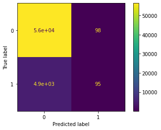

```python
# plot confusion matrix
plot_confusion_matrix(logistic_clf, x_test, y_test)
plt.show()
```

```python
# add accuracy score to results table
results.loc[1] = ['Logistic Regression', 'App, agg prev app & bal, agg bureau & bal data  w/ NZV features', np.round(logistic_train_mean_accuracy_score*100, 2), np.round(logistic_test_score*100, 2),
                  np.round(logistic_train_mean_roc_score*100, 2), np.round(logistic_test_roc_score*100, 2), logistic_grid_search.best_params_]

# show results
results
```

|  | model | Experiment | Train Accuracy | Test Accuracy | Train Area under ROC | Test Area under ROC | Best Parameters |
| --- | --- | --- | --- | --- | --- | --- | --- |
| 0 | Logistic Regression (Baseline) | All application data features | 91.91 | 91.93 | 74.17 | 74.48 | {'logistic__C': 0.1, 'logistic__l1_ratio': 0.6} |
| 1 | Logistic Regression | App, agg prev app & bal, agg bureau & bal data w/ NZV features | 91.93 | 91.92 | 76.56 | 76.81 | {'logistic__C': 0.01, 'logistic__l1_ratio': 0.2} |

#### Feature Importance

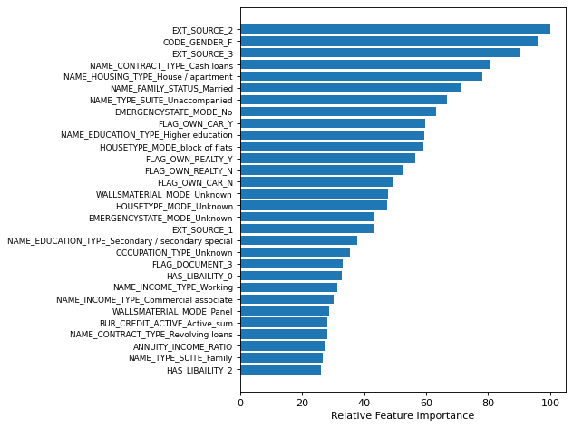

```
There are 73 features that have 0 importance.
```

```python
# plot the feature importance
lr_feature_importance_plot(clf=logistic_clf, names=get_feature_names(logistic_clf, zv = True, feature_selection = False), n=30)
```

### XGBoost

```python
# fit best estimator on entire training data
xgb_clf = xgb_grid_search.best_estimator_.fit(x_train, y_train)

# generate predictions on test data
xgb_predictions = xgb_clf.predict(x_test)

# calculate score on test predictions
xgb_test_score = accuracy_score(y_test, xgb_predictions)

# calculate roc_auc score on test predictions
xgb_test_roc_score = roc_auc_score(y_test, xgb_clf.predict_proba(x_test)[:, 1])

# calculate classification report on test predictions
xgb_test_classification_report = classification_report(y_test, logistic_predictions)

# calculate confusion matrix on test predictions
xgb_test_confusion_matrix = confusion_matrix(y_test, logistic_predictions)
```

```python
# display the classification report
print(xgb_test_classification_report)
```

[output not shown]

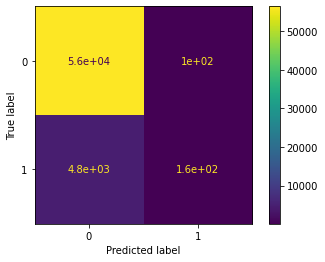

```python
# plot confusion matrix
plot_confusion_matrix(xgb_clf, x_test, y_test)
plt.show()
```

```python
# add accuracy score to results table
results.loc[2] = ['XGBoost', 'App, agg prev app & bal, agg bureau & bal data w/ NZV features', np.round(xgb_train_mean_accuracy_score*100, 2), np.round(xgb_test_score*100, 2),
                  np.round(xgb_train_mean_roc_score*100, 2), np.round(xgb_test_roc_score*100, 2), xgb_grid_search.best_params_]

# show results
results
```

|  | model | Experiment | Train Accuracy | Test Accuracy | Train Area under ROC | Test Area under ROC | Best Parameters |
| --- | --- | --- | --- | --- | --- | --- | --- |
| 0 | Logistic Regression (Baseline) | All application data features | 91.91 | 91.93 | 74.17 | 74.48 | {'logistic__C': 0.1, 'logistic__l1_ratio': 0.6} |
| 1 | Logistic Regression | App, agg prev app & bal, agg bureau & bal data w/ NZV features | 91.93 | 91.92 | 76.56 | 76.81 | {'logistic__C': 0.01, 'logistic__l1_ratio': 0.2} |
| 2 | XGBoost | App, agg prev app & bal, agg bureau & bal data w/ NZV features | 91.98 | 92.03 | 78.27 | 78.70 | {'xgb__colsample_bytree': 0.1, 'xgb__learning_rate': 0.1, 'xgb__max_depth': 3, 'xgb__n_estimators': 300} |

#### Feature Importance

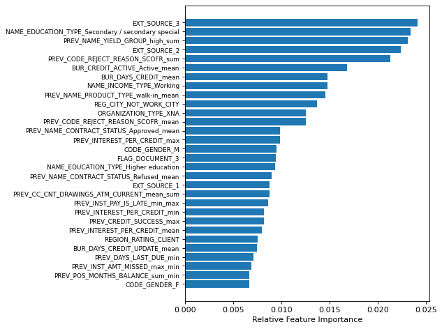

```
There are 414 features that have 0 importance.
```

```python
# plot the feature importance
tree_feature_importance_plot(clf=xgb_clf, names=get_feature_names(xgb_clf, zv = True, feature_selection = False), step_name='xgb' ,n=30)
```

### XGBoost w/ PCA (95% of variance)

```python
# fit best estimator on entire training data
xgb_pca_clf = xgb_pca_grid_search.best_estimator_.fit(x_train, y_train)

# generate predictions on test data
xgb_pca_predictions = xgb_pca_clf.predict(x_test)

# calculate score on test predictions
xgb_pca_test_score = accuracy_score(y_test, xgb_pca_predictions)

# calculate roc_auc score on test predictions
xgb_pca_test_roc_score = roc_auc_score(y_test, xgb_pca_clf.predict_proba(x_test)[:, 1])

# calculate classification report on test predictions
xgb_pca_test_classification_report = classification_report(y_test, xgb_pca_predictions)

# calculate confusion matrix on test predictions
xgb_pca_test_confusion_matrix = confusion_matrix(y_test, xgb_pca_predictions)
```

```python
xgb_pca_clf.named_steps['pca'].n_components
```

```
0.95
```

```python
# display the classification report
print(xgb_pca_test_classification_report)
```

```
              precision    recall  f1-score   support

           0       0.92      1.00      0.96     56538
           1       0.66      0.00      0.01      4965

    accuracy                           0.92     61503
   macro avg       0.79      0.50      0.48     61503
weighted avg       0.90      0.92      0.88     61503
```

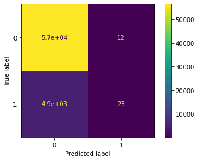

```python
# plot confusion matrix
plot_confusion_matrix(xgb_pca_clf, x_test, y_test)
plt.show()
```

```python
# add accuracy score to results table
results.loc[3] = ['XGBoost', 'App, agg prev app & bal, agg bureau & bal data w/ PCA', np.round(xgb_pca_train_mean_accuracy_score*100, 2), np.round(xgb_pca_test_score*100, 2),
                  np.round(xgb_pca_train_mean_roc_score*100, 2), np.round(xgb_pca_test_roc_score*100, 2), xgb_pca_grid_search.best_params_]

# show results
results
```

|  | model | Experiment | Train Accuracy | Test Accuracy | Train Area under ROC | Test Area under ROC | Best Parameters |
| --- | --- | --- | --- | --- | --- | --- | --- |
| 0 | Logistic Regression (Baseline) | All application data features | 91.91 | 91.93 | 74.17 | 74.48 | {'logistic__C': 0.1, 'logistic__l1_ratio': 0.6} |
| 1 | Logistic Regression | App, agg prev app & bal, agg bureau & bal data w/ NZV features | 91.93 | 91.92 | 76.56 | 76.81 | {'logistic__C': 0.01, 'logistic__l1_ratio': 0.2} |
| 2 | XGBoost | App, agg prev app & bal, agg bureau & bal data w/ NZV features | 91.98 | 92.03 | 78.27 | 78.70 | {'xgb__colsample_bytree': 0.1, 'xgb__learning_rate': 0.1, 'xgb__max_depth': 3, 'xgb__n_estimators': 300} |
| 3 | XGBoost | App, agg prev app & bal, agg bureau & bal data w/ PCA | 91.93 | 91.95 | 75.26 | 75.36 | {'xgb__colsample_bytree': 0.2, 'xgb__learning_rate': 0.1, 'xgb__max_depth': 3, 'xgb__n_estimators': 300} |

#### Feature Importance

```python
xgb_pca_clf
```

```
Pipeline(memory=None,
         steps=[('preparation',
                 ColumnTransformer(n_jobs=None, remainder='passthrough',
                                   sparse_threshold=0.3,
                                   transformer_weights=None,
                                   transformers=[('num_pipeline',
                                                  Pipeline(memory=None,
                                                           steps=[('imputer',
                                                                   SimpleImputer(add_indicator=False,
                                                                                 copy=True,
                                                                                 fill_value=None,
                                                                                 missing_values=nan,
                                                                                 strategy='median',
                                                                                 verbose=0)),
                                                                  ('std_scaler',
                                                                   StandardScaler(...
                 XGBClassifier(base_score=0.5, booster='gbtree',
                               colsample_bylevel=1, colsample_bynode=1,
                               colsample_bytree=0.2, gamma=0, learning_rate=0.1,
                               max_delta_step=0, max_depth=3,
                               min_child_weight=1, missing=None,
                               n_estimators=300, n_jobs=1, nthread=None,
                               objective='binary:logistic', random_state=42,
                               reg_alpha=0, reg_lambda=1, scale_pos_weight=1,
                               seed=None, silent=None, subsample=1,
                               verbosity=1))],
         verbose=False)
```

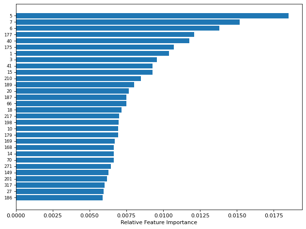

```
There are 85 features that have 0 importance.
```

```python
# plot the feature importance
tree_feature_importance_plot(clf=xgb_pca_clf, pca=True, step_name='xgb', n=30)
```

### XGBoost w/ Feature Selection

```python
# fit best estimator on entire training data
xgb_fs_clf = xgb_fs_grid_search.best_estimator_.fit(x_train, y_train)

# generate predictions on test data
xgb_fs_predictions = xgb_fs_clf.predict(x_test)

# calculate score on test predictions
xgb_fs_test_score = accuracy_score(y_test, xgb_fs_predictions)

# calculate roc_auc score on test predictions
xgb_fs_test_roc_score = roc_auc_score(y_test, xgb_fs_clf.predict_proba(x_test)[:, 1])

# calculate classification report on test predictions
xgb_fs_test_classification_report = classification_report(y_test, xgb_fs_predictions)

# calculate confusion matrix on test predictions
xgb_fs_test_confusion_matrix = confusion_matrix(y_test, xgb_fs_predictions)
```

```python
# display the classification report
print(xgb_fs_test_classification_report)
```

```
              precision    recall  f1-score   support

           0       0.92      1.00      0.96     56538
           1       0.60      0.03      0.06      4965

    accuracy                           0.92     61503
   macro avg       0.76      0.52      0.51     61503
weighted avg       0.90      0.92      0.89     61503
```

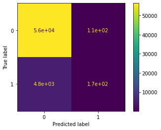

```python
# plot confusion matrix
plot_confusion_matrix(xgb_fs_clf, x_test, y_test)
plt.show()
```

```python
# add accuracy score to results table
results.loc[4] = ['XGBoost', 'App, agg prev app & bal, agg bureau & bal data w/ feature selection', np.round(xgb_fs_train_mean_accuracy_score*100, 2), np.round(xgb_fs_test_score*100, 2),
                  np.round(xgb_fs_train_mean_roc_score*100, 2), np.round(xgb_fs_test_roc_score*100, 2), xgb_fs_grid_search.best_params_]

# show results
results
```

|  | model | Experiment | Train Accuracy | Test Accuracy | Train Area under ROC | Test Area under ROC | Best Parameters |
| --- | --- | --- | --- | --- | --- | --- | --- |
| 0 | Logistic Regression (Baseline) | All application data features | 91.91 | 91.93 | 74.17 | 74.48 | {'logistic__C': 0.1, 'logistic__l1_ratio': 0.6} |
| 1 | Logistic Regression | App, agg prev app & bal, agg bureau & bal data w/ NZV features | 91.93 | 91.92 | 76.56 | 76.81 | {'logistic__C': 0.01, 'logistic__l1_ratio': 0.2} |
| 2 | XGBoost | App, agg prev app & bal, agg bureau & bal data w/ NZV features | 91.98 | 92.03 | 78.27 | 78.70 | {'xgb__colsample_bytree': 0.1, 'xgb__learning_rate': 0.1, 'xgb__max_depth': 3, 'xgb__n_estimators': 300} |
| 3 | XGBoost | App, agg prev app & bal, agg bureau & bal data w/ PCA | 91.93 | 91.95 | 75.26 | 75.36 | {'xgb__colsample_bytree': 0.2, 'xgb__learning_rate': 0.1, 'xgb__max_depth': 3, 'xgb__n_estimators': 300} |
| 4 | XGBoost | App, agg prev app & bal, agg bureau & bal data w/ feature selection | 91.99 | 92.02 | 78.27 | 78.67 | {'xgb__colsample_bytree': 0.1, 'xgb__learning_rate': 0.1, 'xgb__max_depth': 3, 'xgb__n_estimators': 300} |

#### Feature Importance

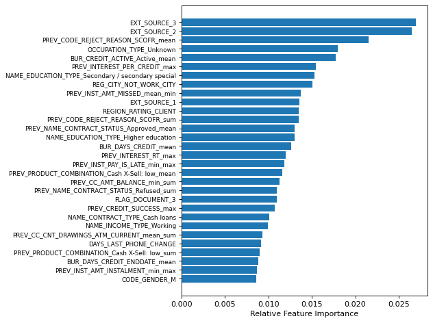

```
There are 13 features that have 0 importance.
```

```python
# plot the feature importance
tree_feature_importance_plot(clf=xgb_fs_clf, names=get_feature_names(xgb_fs_clf, zv = True, feature_selection = True), step_name='xgb', n=30)
```

### Light GBM

```python
# fit best estimator on entire training data
lgbm_clf = lgbm_grid_search.best_estimator_.fit(x_train, y_train)

# generate predictions on test data
lgbm_predictions = lgbm_clf.predict(x_test)

# calculate score on test predictions
lgbm_test_score = accuracy_score(y_test, lgbm_predictions)

# calculate roc_auc score on test predictions
lgbm_test_roc_score = roc_auc_score(y_test, lgbm_clf.predict_proba(x_test)[:, 1])

# calculate classification report on test predictions
lgbm_test_classification_report = classification_report(y_test, lgbm_predictions)

# calculate confusion matrix on test predictions
lgbm_test_confusion_matrix = confusion_matrix(y_test, lgbm_predictions)
```

```python
# display the classification report
print(lgbm_test_classification_report)
```

```
              precision    recall  f1-score   support

           0       0.92      1.00      0.96     56538
           1       0.63      0.03      0.05      4965

    accuracy                           0.92     61503
   macro avg       0.77      0.51      0.50     61503
weighted avg       0.90      0.92      0.88     61503
```

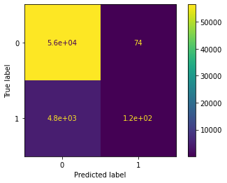

```python
# plot confusion matrix
plot_confusion_matrix(lgbm_clf, x_test, y_test)
plt.show()
```

```python
# add accuracy score to results table
results.loc[5] = ['LightGBM', 'App, agg prev app & bal, agg bureau & bal data w/ NZV features', np.round(lgbm_train_mean_accuracy_score*100, 2), np.round(lgbm_test_score*100, 2),
                  np.round(lgbm_train_mean_roc_score*100, 2), np.round(lgbm_test_roc_score*100, 2), lgbm_grid_search.best_params_]

# show results
results
```

|  | model | Experiment | Train Accuracy | Test Accuracy | Train Area under ROC | Test Area under ROC | Best Parameters |
| --- | --- | --- | --- | --- | --- | --- | --- |
| 0 | Logistic Regression (Baseline) | All application data features | 91.91 | 91.93 | 74.17 | 74.48 | {'logistic__C': 0.1, 'logistic__l1_ratio': 0.6} |
| 1 | Logistic Regression | App, agg prev app & bal, agg bureau & bal data w/ NZV features | 91.93 | 91.92 | 76.56 | 76.81 | {'logistic__C': 0.01, 'logistic__l1_ratio': 0.2} |
| 2 | XGBoost | App, agg prev app & bal, agg bureau & bal data w/ NZV features | 91.98 | 92.03 | 78.27 | 78.70 | {'xgb__colsample_bytree': 0.1, 'xgb__learning_rate': 0.1, 'xgb__max_depth': 3, 'xgb__n_estimators': 300} |
| 3 | XGBoost | App, agg prev app & bal, agg bureau & bal data w/ PCA | 91.93 | 91.95 | 75.26 | 75.36 | {'xgb__colsample_bytree': 0.2, 'xgb__learning_rate': 0.1, 'xgb__max_depth': 3, 'xgb__n_estimators': 300} |
| 4 | XGBoost | App, agg prev app & bal, agg bureau & bal data w/ feature selection | 91.99 | 92.02 | 78.27 | 78.67 | {'xgb__colsample_bytree': 0.1, 'xgb__learning_rate': 0.1, 'xgb__max_depth': 3, 'xgb__n_estimators': 300} |
| 5 | LightGBM | App, agg prev app & bal, agg bureau & bal data w/ NZV features | 91.98 | 92.01 | 78.03 | 78.48 | {'lgbm__boosting_type': 'goss', 'lgbm__colsample_bytree': 0.1, 'lgbm__learning_rate': 0.005, 'lgbm__max_depth': 2, 'lgbm__n_estimators': 7000} |

#### Feature Importance

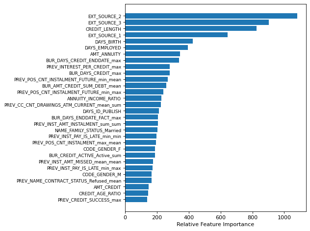

```
There are 268 features that have 0 importance.
```

```python
# plot feature importance
tree_feature_importance_plot(clf=lgbm_clf, step_name='lgbm', names=get_feature_names(lgbm_clf, zv=True), n=30)
```

### Light GBM w/ Feature Selection

```python
# fit best estimator on entire training data
lgbm_fs_clf = lgbm_fs_grid_search.best_estimator_.fit(x_train, y_train)

# generate predictions on test data
lgbm_fs_predictions = lgbm_fs_clf.predict(x_test)

# calculate score on test predictions
lgbm_fs_test_score = accuracy_score(y_test, lgbm_fs_predictions)

# calculate roc_auc score on test predictions
lgbm_fs_test_roc_score = roc_auc_score(y_test, lgbm_fs_clf.predict_proba(x_test)[:, 1])

# calculate classification report on test predictions
lgbm_fs_test_classification_report = classification_report(y_test, lgbm_fs_predictions)

# calculate confusion matrix on test predictions
lgbm_fs_test_confusion_matrix = confusion_matrix(y_test, lgbm_fs_predictions)
```

```python
# display the classification report
print(lgbm_fs_test_classification_report)
```

```
              precision    recall  f1-score   support

           0       0.92      1.00      0.96     56538
           1       0.63      0.03      0.05      4965

    accuracy                           0.92     61503
   macro avg       0.78      0.51      0.50     61503
weighted avg       0.90      0.92      0.88     61503
```

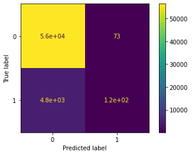

```python
# plot confusion matrix
plot_confusion_matrix(lgbm_fs_clf, x_test, y_test)
plt.show()
```

```python
# add accuracy score to results table
results.loc[6] = ['LightGBM', 'App, agg prev app & bal, agg bureau & bal data  w/ feature selection', np.round(lgbm_fs_train_mean_accuracy_score*100, 2), np.round(lgbm_fs_test_score*100, 2),
                  np.round(lgbm_fs_train_mean_roc_score*100, 2), np.round(lgbm_fs_test_roc_score*100, 2), lgbm_fs_grid_search.best_params_]

# show results
results
```

|  | model | Experiment | Train Accuracy | Test Accuracy | Train Area under ROC | Test Area under ROC | Best Parameters |
| --- | --- | --- | --- | --- | --- | --- | --- |
| 0 | Logistic Regression (Baseline) | All application data features | 91.91 | 91.93 | 74.17 | 74.48 | {'logistic__C': 0.1, 'logistic__l1_ratio': 0.6} |
| 1 | Logistic Regression | App, agg prev app & bal, agg bureau & bal data w/ NZV features | 91.93 | 91.92 | 76.56 | 76.81 | {'logistic__C': 0.01, 'logistic__l1_ratio': 0.2} |
| 2 | XGBoost | App, agg prev app & bal, agg bureau & bal data w/ NZV features | 91.98 | 92.03 | 78.27 | 78.70 | {'xgb__colsample_bytree': 0.1, 'xgb__learning_rate': 0.1, 'xgb__max_depth': 3, 'xgb__n_estimators': 300} |
| 3 | XGBoost | App, agg prev app & bal, agg bureau & bal data w/ PCA | 91.93 | 91.95 | 75.26 | 75.36 | {'xgb__colsample_bytree': 0.2, 'xgb__learning_rate': 0.1, 'xgb__max_depth': 3, 'xgb__n_estimators': 300} |
| 4 | XGBoost | App, agg prev app & bal, agg bureau & bal data w/ feature selection | 91.99 | 92.02 | 78.27 | 78.67 | {'xgb__colsample_bytree': 0.1, 'xgb__learning_rate': 0.1, 'xgb__max_depth': 3, 'xgb__n_estimators': 300} |
| 5 | LightGBM | App, agg prev app & bal, agg bureau & bal data w/ NZV features | 91.98 | 92.01 | 78.03 | 78.48 | {'lgbm__boosting_type': 'goss', 'lgbm__colsample_bytree': 0.1, 'lgbm__learning_rate': 0.005, 'lgbm__max_depth': 2, 'lgbm__n_estimators': 7000} |
| 6 | LightGBM | App, agg prev app & bal, agg bureau & bal data w/ feature selection | 91.99 | 92.01 | 78.02 | 78.48 | {'lgbm__boosting_type': 'goss', 'lgbm__colsample_bytree': 0.1, 'lgbm__learning_rate': 0.005, 'lgbm__max_depth': 2, 'lgbm__n_estimators': 7000} |

#### Feature Importance

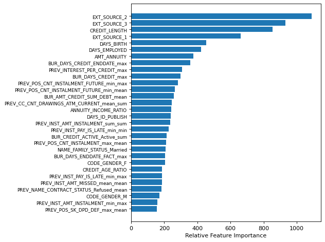

```
There are 0 features that have 0 importance.
```

```python
# plot feature importance
tree_feature_importance_plot(clf=lgbm_fs_clf, step_name='lgbm', names=get_feature_names(lgbm_fs_clf, zv=True, feature_selection = True), n=30)
```

## Kaggle Submission

### XGBoost

```python
# predict the test data
predictions = xgb_clf.predict_proba(appTestDF)[:, 1]
```

```python
# kaggle submission
submission = pd.DataFrame({'SK_ID_CURR':appTestDF['SK_ID_CURR'],'TARGET':predictions})

submission.head()
```

|  | SK_ID_CURR | TARGET |
| --- | --- | --- |
| 0 | 100001 | 0.051735 |
| 1 | 100005 | 0.135378 |
| 2 | 100013 | 0.025999 |
| 3 | 100028 | 0.035316 |
| 4 | 100038 | 0.165772 |

```python
# write out kaggle submission file
filename = SUBMISSION_DIR + '/hcdr_kaggle_submission_phase2.csv'

submission.to_csv(filename,index=False)
```

### Save best model

```python
import pickle
file_name = MODEL_DIR + '/xgb_phase2_clf.pkl'

# save
pickle.dump(xgb_clf, open(file_name, "wb"))
```

# Write up

## Abstract

Many consumers struggle receiving loan support from banks due to lacking credit history. Home Credit is a service whose goal is to provide loan opportunities for this underserved population. Failing to build and implement an accurate repayment detection method assumes major consequences. Missed financial interest unfolds if a loan is granted to consumers likely to default, Home Credit may not recoup the principal. This paper aims to address this issue by proposing a machine learning approach using Home Credit internal and external loan application and credit payment history data for automatic loan default detection. We introduce a simple and explainable logistic regression algorithm with the loan application data. Additionally, we explore more advanced machine learning and deep learning algorithms such as gradient boosting machines and neural networks to improve default classification. The results will show strong performance comparable to existing algorithms scoring near the top of the open-source Kaggle leaderboard.

## Introduction

The main project objective is to build a machine learning classification algorithm with current and existing loan application and payment history data to determine if a new Home Credit loan applicant will default on a loan. This project will abide by the Cross Industry Standard Process for Data Mining (CRISP-DM) framework to build a valuable default detection system. The CRISP-DM framework consists of six revolving sections: business understanding, data understanding, data preparation, modeling, evaluation, and deployment. Since this modeling exercise is for research purposes only, the deployment step is ignored. The first phase of the project was to complete one iteration with available data to model and evaluate a regularized logistic regression model for default detection. The second phase of the project was to continue to build on the initial model build, focusing on enhancing feature engineering and introducing model tuning. The above file contains some additional exploratory data analysis, feature engineering, model tuning, and model results compated to the initial baseline model for the project "Identifying Home Credit Application Default Risk". Modeling has been performed using the data extracted from [Home Credit Default Risk (HCDR) Kaggle Competition](https://www.kaggle.com/c/home-credit-default-risk/).

[figure not shown]

## Data

Data provided by Home Credit is available from the Kaggle website in CSV format. A brief description of the available data is mentioned below:

[figure not shown]

The main data available is loan application information at Home Credit. This data contains most information about the client – gender, income, family status, education, etc. Train and test versions of this data is available.

The train version of the file contains the “TARGET” field, which has a value of either “0” or “1”. “0” indicates that a loan has been repaid, whereas “1” indicates that a loan has not been repaid. The test version of the file does not contain the “TARGET” field. 307.5 thousand records with 122 columns are present in the train version of the data for model building, tuning, and validation, whereas 48.7 thousand records with 121 columns are present in the test version of the data for model evaluation. The six other sources of data supplement the loan application data to achieve higher accuracy.

The bureau data contains information about every client’s financial information from the various institutions. Prior loan information is present, and it has its own row in this file. 1.7m records with 17 columns are present in this file. The bureau balance data contains monthly data about previous credits in each bureau. A single credit can be present in multiple rows – one for each month of the credit length. 27.3 million records with 3 columns are present in this file.

The previous application file contains information about client’s previous loan in Home Credit. Various loan parameters from the past along with client information at the time of previous application is available. Each prior application has one row in this file. Each row is uniquely identified by a primary key – SK_ID_PREV. 1.7 million records along with 37 columns are present in this file. The point of sales cash balance, installment payments, and credit card balance for this data is also available in subsequent files.

The point-of-sale cash balance data contains monthly balance information maintained by clients in their previous loan in Home Credit. Each row contains one month of a credit balance, and a single credit can be present in multiple rows. 10 million records along with 8 columns are present in this data.

The installments payment data contains information about installment payments made by the clients in their previous loan in Home Credit. One row for every payment made and one row for every payment missed is present in this file. 13.6 million records along with 8 columns are present in this data.

The Credit Card Balance data contains information about monthly balances maintained by the clients in their previous credit card loans in Home Credit. 3.8 million records along with 23 columns are present in this data.

## EDA Summary

The target value distribution has been explored on the training dataset. There is an imbalance between the number of records indicating that the loan was repaid and those indicating that the loan was not repaid.

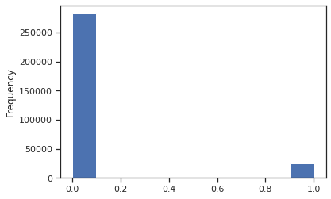

```python
appTrainDF['TARGET'].astype(int).plot.hist();
```

The correlation of the fields against the target column has been explored and provided below:

```python
correlations = appTrainDF.corr()['TARGET'].sort_values()

print('Most Positive Correlations with TARGET - Top 10:')
print(correlations.tail(10))

print('\nMost Negative Correlations with TARGET - Top 10:')
print(correlations.head(10))
```

```
Most Positive Correlations with TARGET - Top 10:
FLAG_DOCUMENT_3                0.044346
REG_CITY_NOT_LIVE_CITY         0.044395
FLAG_EMP_PHONE                 0.045982
REG_CITY_NOT_WORK_CITY         0.050994
DAYS_ID_PUBLISH                0.051457
DAYS_LAST_PHONE_CHANGE         0.055218
REGION_RATING_CLIENT           0.058899
REGION_RATING_CLIENT_W_CITY    0.060893
DAYS_BIRTH                     0.078239
TARGET                         1.000000
Name: TARGET, dtype: float64

Most Negative Correlations with TARGET - Top 10:
EXT_SOURCE_3                 -0.178919
EXT_SOURCE_2                 -0.160472
EXT_SOURCE_1                 -0.155317
DAYS_EMPLOYED                -0.044932
FLOORSMAX_AVG                -0.044003
FLOORSMAX_MEDI               -0.043768
FLOORSMAX_MODE               -0.043226
AMT_GOODS_PRICE              -0.039645
REGION_POPULATION_RELATIVE   -0.037227
ELEVATORS_AVG                -0.034199
Name: TARGET, dtype: float64
```

The percentage of missing values has been checked on the training dataset. There are no columns with more than 70% missing data. However, there are 17 columns which have over 60% missing data.

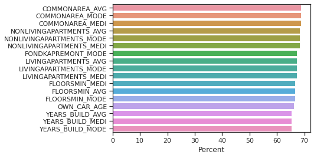

```python
sns.barplot(y=missing_application_train_data.head(17).index, x=missing_application_train_data.head(17).Percent)
```

## Model building and evaluation

The initial baseline model is fit only with the application data set to predict credit default.

Subsequent models are fit with features from all available data sets (application, previous application, credit balance, installment payments, point of sale cash balance, bureau, and bureau balance) to build a more accurate model.

Data is split such that 80% is in training data and 20% is held out in testing data  
5 fold cross validation will be used for tuning and estimating accuracy before evaluating on test data - see tuning section below.

A standard 4 Core and 16 GB RAM does not have enough compute power to train a model of this size. Thus we will do an additional split with the training data in order for performing hyperparameter tuning. Additionally, *Google Colab Pro* is used in phase two as the feature space increases significantly when introducing new data.

The hyperparameter tuning will be completed using a random 10% of the training data. The hyperparameters will be chosen based on the subset generating the highest 5 fold validation area under the roc curve.

We will use the remaining 90% of the training data to perform 5 fold cross validation with the best hyperparameters from the tuning process to gather estimates of how the model will perform on unseen data.

[figure not shown]

**Phase 1 Baseline**

The baseline model in phase 1 is an elastic net logistic regression model (0.1 penalty and 0.6 L1 ratio) fit using all application data features. The model achieved a 74.48 area under the ROC curve score. The best model from phase 1 was the XGBoost model fit using all application data features. The model chieved a 75.80 area under the ROC curve score. The model scores from phase 1 suggested a boosting tree based model would likely perform better and more emphasis was placed on generating new features and tuning these types of models in phase 2.

**Phase 2 Experiments**

For phase 2, there were four types of algorithms explored: elastic net logistic regression, random forest, xgboost, and lightGBM.

There were several experiments tested with different subsets of features and algorithms (some of the tests are not included in the notebook above as they did not return better results than previous experiments):

- Elastic Net Logistic Regression with all loan application features (baseline)
- Elastic Net Logistic Regression with all loan application features plus aggregated previous application, credit balance, installment payments, point of sale cash balance, bureau, and bureau balance features. Additional domain features added such as credit to income ratio and interest rate features are added.
- Random Forest with all loan application features plus aggregated previous application, credit balance, installment payments, point of sale cash balance, bureau, and bureau balance features. Additional domain features added such as credit to income ratio and interest rate features are added (not included as low performance).
- XGBoost with all loan application features plus aggregated previous application, credit balance, installment payments, point of sale cash balance, bureau, and bureau balance features. Additional domain features added such as credit to income ratio and interest rate features are added.
- LightGBM with all loan application features plus aggregated previous application, credit balance, installment payments, point of sale cash balance, bureau, and bureau balance features. Additional domain features added such as credit to income ratio and interest rate features are added.

For each feature set and algorithm, the first model is fit with all loan application features plus aggregated previous application, credit balance, installment payments, point of sale cash balance, bureau, and bureau balance features which have non-zero variance.

The second model uses feature importances from the first model to remove features with 0 importance and is subsequently refit.

The third model fit attempts to use principal components analysis to reduce the feature set using the components that capture 95% of the variance within the input data. (only the XGBoost model using PCA is included above as all PCA results performed worse than no PCA)

**Phase 2 Additional Experiments**

In additional to the models shown in the notebook, we also fit models attempting to mitigate the moderate class imbalance with default only happening in 8% of applications. An additional synthetic data augmentation step was added to each model fit described above. The Synthetic Minority Over-sampling Technique (SMOTE) added synthetically generated samples from the minority class such that the minority class was at a 50% ratio to the majority class. The training and tuning runs with this experiment consumed hours of machine time and did not generate a boost in results. Because there was not a boost in results, the models are not included in this notebook.

**Phase 2 Tuning**

All models are tuned using a grid search with candidate parameters. Candidate parameters are adjusted subsequently after model runs if the candidate parameter chosen is at the boundary. For example, if 500 trees in an XGBoost is the max trees allowed in the grid search and that is the best selected, an additional model is fit with an expanded candidate space for number of trees. Other methods such as Bayesian optimization were explored, however performance and package management grew an increasing issue to implement.

The logistic regression model is tuned to determine the optimal mixture of L1 and L2 regularization and the amount of regularization.

The random forest algorithm is tuned to determine the optimal number of trees, maximum number of features, maximum tree depth, minimum split size, and minimum samples in a leaf.

Lastly the XGBoost and lightGBM models are tuned to determine the number of trees, learning rate, maximum tree depth, and columns sampled by each tree.

The main metric to optimize is area under ROC curve. The best performing model from the 5-fold cross validation will be fit on the entire training data and used to generate the second submission to the kaggle competition.

The additional metrics used to evaluate performance on the test data set are precision, recall, f1 score, classification accuracy, and the confusion matrix which compares the class predictions to the actual default status.

## Feature Engineering and transformers

### Features

The subsequent models fit in phase 2 leverage application data features plus aggregated previous application, credit balance, installment payments, point of sale cash balance, bureau, and bureau balance features to optimize model performance. Several additional domain features are added such as credit to income ratio and interest rate. More detail on the added features is captured in the *New features* section

Features from the previous application, credit balance, installment payments, point of sale cash balance, bureau, and bureau balance need to be aggregated to the application level. It is possible for an applicant to have several previous loans. In this case, aggregate features need to be added to capture and quantify the applicant's previous loans. For each of the previous loans, the loan will have several months of balance history. This data will require aggregation twice (first to the previous application level and then to the application level).

There are over 200 possible features within the available datasets. It is important to exhibit a form of automated feature engineering in early model runs to detect which features capture the most signal. All numeric features in the data will be aggregated using count, sum, mean, min, and max. All categorical features will be aggregated using count, sum, and mean. Balance features are aggregated twice, while the previous application and bureau features are aggregated once.

[figure not shown]

### Feature Additions

For the second set of models, additional loan specific features are added to the data including:

**Application**

- Credit to income ratio
- Annuity to income ratio
- Credit term length
- Income to age ratio
- Credit to age ratio
- % of life employed at current company

The below added features will be aggregated to the application data using count, sum, min, max, mean.

**Previous application**

- Interest Paid
- Interest paid per credit
- Was credit fully paid?
- Interest rate

**Credit Card Balance**

- Late payment
- Payment amount missed

**Installment Payments**

- Missed days past due
- Credit limit used
- Minimum credit amount missing

The results of the baseline model will be compared to the results of the model with the additional features added. Whichever feature set performs better will be selected as the best model to submit

The baseline model results will be compared to the results from the subsequent models using area under the roc curve, classification accuracy, precision, and recall.

We will assess feature importance after model fitting to identify the top features to select for additional modeling. All of the added features hold importance in our final model run

As the feature space grows rapidly from adding features from the other subsets, feature selection steps will be applied to remove features. Features with high missingness, collinear features, and features will little feature importance will be removed within pipeline steps to reduce the feature space and optimize the data to predict default.

## Pipelines

### Data prep

The data preparation pipeline takes as input the raw available data and combines all datasets into one training and one testing data set. The pipeline consists of several steps to add new features, aggregate balance and previous loan features, remove highly missing features and collinear features, and merge to the loan application data. The steps of the data preparation pipeline are listed below:

**Previous application data prep**

- **Step 1:** New features from the EDA are added to POS cash balance, installment payment, and credit card data
- **Step 2:** One hot encode categorical features in POS cash balance, installment payment, and credit card balance data sets for categorical features
- **Step 3:** Aggregate numeric features by calculating min, max, mean, count, and sum for each feature. Aggregate the categorical features by taking the mean, count, and sum.
- **Step 4:** After aggregating, remove columns that have high amounts of missing data and are highly collinear with other columns. This is a great way to reduce the feature space before storing the file.
- **Step 5:** Join the balance data sets to the previous application data separately.
- **Step 6:** For joined previous application datasets: Aggregate numeric features by calculating min, max, mean, count, and sum for each min, max, mean, count, and sum feature. Aggregate the categorical features by taking the mean, count, and sum for each mean, count, and sum feature created previously.
- **Step 7:** After aggregating, remove columns that have high amounts of missing data and are highly collinear with other columns. This is a great way to reduce the feature space before storing the file.
- **Step 8:** Join the aggregated previous application data to the application data by SK_ID_CURR

**Bureau data prep**

- **Step 1:** One hot encode categorical features in bureau balance data for categorical features
- **Step 2:** Aggregate numeric features by calculating min, max, mean, count, and sum for each feature. Aggregate the categorical features by taking the mean, count, and sum.
- **Step 3:** After aggregating, remove columns that have high amounts of missing data and are highly collinear with other columns. This is a great way to reduce the feature space before storing the file.
- **Step 4:** Join the balance data sets to the bureau data separately.
- **Step 5:** For joined bureau datasets: Aggregate numeric features by calculating min, max, mean, count, and sum for each min, max, mean, count, and sum feature. Aggregate the categorical features by taking the mean, count, and sum for each mean, count, and sum feature created previously.
- **Step 6:** After aggregating, remove columns that have high amounts of missing data and are highly collinear with other columns. This is a great way to reduce the feature space before storing the file.
- **Step 7:** Join the aggregated bureau data to the application data by SK_ID_CURR

**Final Step:** Once all data sets have been joined, add in new application features and remove zero variance features.

### Model building

The model building data pipeline for the input features from the data prep pipeline consists of 7 steps for the initial model building phase. There are two transformations applied to numeric features and two transformations applied to categorical features. The steps of the data prep modeling pipeline are listed below:

- **Step 1:** Impute missing numeric values with the median as some features are heavily skewed and the median reflects the most accurate guess at the true value for most numeric features in the data
- **Step 2:** Standardize the numeric features such that all numeric and categorical features within the dataset are of the same scale.
- **Step 3:** Impute the missing categorical features with a "Unknown" category. Missing values are assigned their own category as missing the feature may be meaningful to detecting default for some features.
- **Step 4:** One hot encode categorical features such that each category is a boolean value of 1 or zero.
- **Step 5:** Remove zero variance features
- **Step 6 (if performing feature selection):** Remove features with zero importance from previous model run with all features
- **Step 7:** Pipe the transformed data into the modeling step of the pipeline (regularized logistic regression/random forest/xgboost)

### Model building pipeline architecture

[figure not shown]

## Models

### Regularized Logistic Regression

Regularized logistic regression (LR) is a generalized linear model with a sigmoid activation function applied to generate probabilities that input data is of a certain class. Logistic regression is a parameterized model optimizing binary cross-entropy loss when learning model coefficients

Due to a large feature space, we will apply elastic net regularization which combines the L1 and L2 penalties to reduce model complexity and perform built in feature selection.

#### Logistic Regression Model Architecture

[figure not shown]

#### Learning a logistic regression model

The objective function for the learning a binary logistic regression model (log loss) is known as the **binary cross-entropy loss (CXE)** function.

This can be expressed directly in terms of perpendicular distances from X to the hyperplane theta as follows:

[figure not shown]

### Gradient Boosting

Gradient boosting is a gradient boosting machine learning model optimized for faster convergence. A gradient boosting machine is a tree-based model which sequentially learns new trees to fit residuals from previous iterations. Thus, observations poorly predicted are sequentially weighted higher for future fits. This modeling technique consistently scores near the top of machine learning competitions.

#### Gradient Boosting Model Architecture

[figure not shown]

#### Learning a gradient boosting classification model

Decision tree learning is a supervised machine learning approach whose goal is to recursively partition the input feature space into different zones to predict the target value. Decision trees use information gain to determine the next optimal split within the tree. Information gain is the expected reduction in entropy from splitting on a particular attribute.

[figure not shown]

Gradient boosting then sequentially learns decision trees to model residuals from previous decision trees.

#### XGBoost vs. LightGBM

There are two variants of gradient boosting explored in this study. XGBoost is a boosting algorithm that historically performs well in machine learning use cases where there are large amounts of features. XGBoost uses level-wise tree growth to grow trees. LightGBM is another variant that uses leaf-wise tree growth. Another major difference between LightGBM and XGBoost is LightGBM discretizes continuous features into bins before performing splits. This leads to increased speed in computation and less memory usage. Because of the speed increase with LightGBM, it is ideal for large datasets and allows for more trees to be fit.

[figure not shown]

## Experimental Results & Discussion

In phase 1, our baseline model was Logistic Regression on the Application dataset alone, and the train area under the ROC was obtained as 74.17. Our best model was XGBoost on the Application dataset with 6 newly engineered features, wherein the train area under the ROC was obtained as 76.29.

In phase 2, we combined the Application dataset along with its subsets, and in addition, we created 16 newly engineered features. The following were the observations from various models:

The final model selected was the XGBoost model using all data sets. The top 3 performing models and additional main models fit within this phase are included below.

In this phase, once again our best performing model was XGBoost but it was on the combined dataset. Our Kaggle scores were 0.78425 (private) and 0.78295 (public).

[figure not shown]

## Conclusion

This project aims to implement an accurate repayment detection method for Home Credit, since inaccurate method will have major consequences. For phase 2, we used all the available datasets and created a combined dataset, along with 16 newly engineered features. We then performed Logistic Regression, XGBoost and LightGBM on this dataset along with tuning the hyperparameters. Our current best model uses XGBoost, wherein we noticed a 4.1% point increase in train area under the ROC compared to our baseline model which used Logistic Regression on only the Application dataset. LightGBM model came close second at 4.0% point increase in train area under the ROC. We did Kaggle submission to the Home Credit Default Risk project, and we obtained a score of 0.78295, which improved on our earlier score of 0.7585. As part of phase 3, we will implement a neural network and continue to work on further improving our accuracy.

## References

Some of the material in this notebook has been adopted from [Start Here: A Gentle Introduction](https://www.kaggle.com/willkoehrsen/start-here-a-gentle-introduction/notebook)

The interest rate field used in this notebook is adopted from [10th place writeup](https://www.kaggle.com/c/home-credit-default-risk/discussion/64598)

The architecture images are sourced from

- [Logistic Regression Architecture](https://www.researchgate.net/publication/334575492/figure/fig7/AS:782432886349826@1563557945492/Architecture-of-a-Logistic-Regression-Model-56.ppm)
- [Random Forest Architecture](https://miro.medium.com/max/2612/0*f_qQPFpdofWGLQqc.png)
- [Gradient Boosting Algorithm Architecture](https://bradleyboehmke.github.io/HOML/images/boosted-trees-process.png)

The difference in LightGBM and XGBoost is sourced from

- [Which algorithm takes the crown: Light GBM vs XGBOOST?](https://www.analyticsvidhya.com/blog/2017/06/which-algorithm-takes-the-crown-light-gbm-vs-xgboost/)